# Trust in political institutions and support for authoritarianism in Latin American students: Does civic knowledge make a difference?

Daniel Miranda, Juan Carlos Castillo, Catalina Miranda & José Conejeros

09/10/2019

Below are descriptive and correlational statistics with data from to the International Civic and Citizenship Education Study (ICCS) 2009 and 2016, in which six (Chile, Mexico, Colombia, Paraguay, Guatemala, and the Dominican Republic) and five (Chile, Mexico, Colombia, Peru, and the Dominican Republic) Latin American countries participated, respectively. The following sections are presented: change in support for dictatorship, support for Dictatorship on civic knowledge and support for Dictatorship on institutional trust

# Data Frames

- ICCS 2009: Chile, Mexico, Colombia, Paraguay, Guatemala, and the Dominican Republic

```r
#ICCS 2009: Latinamerica module, student questionnaire: Hay dos bases, unas que cuentan con la información respectiva al cuestionario y otras que refieren a la prueba de conocimiento cívico. Al unir ambas bases se pierden observaciones.  Revisar Merge.

#Chile
chi09 <-  as.data.frame(read_sas("ICCS2009_IDB_SAS/Data_G8/islchlc2.sas7bdat"))
chi092 <-  as.data.frame(read_sas("ICCS2009_IDB_SAS/Data_G8/isgchlc2.sas7bdat"))
chi     <- merge(chi09, chi092, by ="IDSTUD", all=FALSE, suffixes = c("",".y"))#Merge
#México
mex09 <-  as.data.frame(read_sas("ICCS2009_IDB_SAS/Data_G8/islmexc2.sas7bdat"))
mex092 <-  as.data.frame(read_sas("ICCS2009_IDB_SAS/Data_G8/isgmexc2.sas7bdat"))
mex   <- merge(mex09, mex092, by="IDSTUD", all=FALSE, suffixes = c("",".y"))#Merge
#Colombia
col09 <- as.data.frame(read_sas("ICCS2009_IDB_SAS/Data_G8/islcolc2.sas7bdat"))
col092 <- as.data.frame(read_sas("ICCS2009_IDB_SAS/Data_G8/isgcolc2.sas7bdat"))
col   <- merge(col09, col092, by="IDSTUD", all=FALSE, suffixes = c("",".y"))#Merge
#Paraguay
pry09 <- as.data.frame(read_sas("ICCS2009_IDB_SAS/Data_G8/islpryc2.sas7bdat"))
pry092 <- as.data.frame(read_sas("ICCS2009_IDB_SAS/Data_G8/isgpryc2.sas7bdat"))
pry   <- merge(pry09, pry092, by="IDSTUD", all=FALSE, suffixes = c("",".y"))#Merge

#Guatemala
gtm09 <- as.data.frame(read_sas("ICCS2009_IDB_SAS/Data_G8/islgtmc2.sas7bdat"))
gtm092 <- as.data.frame(read_sas("ICCS2009_IDB_SAS/Data_G8/isggtmc2.sas7bdat"))
gtm   <- merge(gtm09, gtm092, by="IDSTUD", all=FALSE, suffixes = c("",".y"))#Merge

#República Dominicana
dom09 <- as.data.frame(read_sas("ICCS2009_IDB_SAS/Data_G8/isldomc2.sas7bdat"))
dom092 <- as.data.frame(read_sas("ICCS2009_IDB_SAS/Data_G8/isgdomc2.sas7bdat"))
dom   <- merge(dom09, dom092, by="IDSTUD", all=FALSE, suffixes = c("",".y"))#Merge

#Append: all obervations preserve
iccs09 <- rbind(chi, mex, col, pry, gtm, dom)
#class(iccs09)
#dim(iccs09)
#head(iccs09)
#str(iccs09)
#names(iccs09)
#dplyr::glimpse(iccs09) # ver estructura general
#ICCS 2009
save(iccs09, file = "BBDD_ICCS/ICCS09.Rdata")
```

- ICCS 2016: Chile, Mexico, Colombia, Peru, and the Dominican Republic

```r
#ICCS 2016: Latinamerica module, student questionnaire
#Chile
chi16 <-  as.data.frame(read_sas("ICCS2016_IDB_SAS/Data/islchlc3.sas7bdat"))
chi162 <-  as.data.frame(read_sas("ICCS2016_IDB_SAS/Data/isgchlc3.sas7bdat"))
chi     <- merge(chi16, chi162, by ="IDSTUD", all=FALSE, suffixes = c("",".y"))#Merge
#México
mex16 <-  as.data.frame(read_sas("ICCS2016_IDB_SAS/Data/islmexc3.sas7bdat"))
mex162 <-  as.data.frame(read_sas("ICCS2016_IDB_SAS/Data/isgmexc3.sas7bdat"))
mex     <- merge(mex16, mex162, by ="IDSTUD", all=FALSE, suffixes = c("",".y"))#Merge
#Colombia
col16 <- as.data.frame(read_sas("ICCS2016_IDB_SAS/Data/islcolc3.sas7bdat"))
col162 <- as.data.frame(read_sas("ICCS2016_IDB_SAS/Data/isgcolc3.sas7bdat"))
col     <- merge(col16, col162, by ="IDSTUD", all=FALSE, suffixes = c("",".y"))#Merge
#República Dominicana
dom16 <- as.data.frame(read_sas("ICCS2016_IDB_SAS/Data/isldomc3.sas7bdat"))
dom162 <- as.data.frame(read_sas("ICCS2016_IDB_SAS/Data/isgdomc3.sas7bdat"))
dom     <- merge(dom16, dom162, by ="IDSTUD", all=FALSE, suffixes = c("",".y"))#Merge
#Perú
per16 <- as.data.frame(read_sas("ICCS2016_IDB_SAS/Data/islperc3.sas7bdat"))
per162 <- as.data.frame(read_sas("ICCS2016_IDB_SAS/Data/isgperc3.sas7bdat"))
per     <- merge(per16, per162, by ="IDSTUD", all=FALSE, suffixes = c("",".y"))#Merge
#Append: all obervations preserve
iccs16 <- rbind(chi, mex, col, dom, per)
rm(chi,mex,col,dom,per,pry,gtm)
#class(iccs16)
#dim(iccs16)
#head(iccs16)
#str(iccs116)
#names(iccs16)
#dplyr::glimpse(iccs16) # ver estructura general
#ICCS 2016
save(iccs16, file = "BBDD_ICCS/ICCS16.Rdata")
#Load Data
load("BBDD_ICCS/ICCS09.Rdata") #29896 obs - 128 vars
load("BBDD_ICCS/ICCS16.Rdata") #25319 obs - 168 vars
#skim(iccs09)
#skim(iccs16)
```

# Process Data

- Process General Databases ICCS 2009 and ICCS 2016

```r
#Directorio imagenes
setwd("GRAPH")
```

## Chile

```r
#2016
names(chi16)
```

[1] “COUNTRY” “IDCNTRY” “IDSTUD” “IDSCHOOL” “IDCLASS”  
[6] “IDPOP” “LS3G01A” “LS3G01B” “LS3G01C” “LS3G01D”  
[11] “LS3G01E” “LS3G01F” “LS3G02A” “LS3G02B” “LS3G02C”  
[16] “LS3G02D” “LS3G02E” “LS3G03A” “LS3G03B” “LS3G03C”  
[21] “LS3G03D” “LS3G03E” “LS3G03F” “LS3G04A” “LS3G04B”  
[26] “LS3G04C” “LS3G04D” “LS3G04E” “LS3G04F” “LS3G04G”  
[31] “LS3G04H” “LS3G04I” “LS3G04J” “LS3G05A” “LS3G05B”  
[36] “LS3G05C” “LS3G05D” “LS3G05E” “LS3G05F” “LS3G05G”  
[41] “LS3G05H” “LS3G05I” “LS3G05J” “LS3G06A” “LS3G06B”  
[46] “LS3G06C” “LS3G06D” “LS3G06E” “LS3G06F” “LS3G06G”  
[51] “LS3G06H” “LS3G07A” “LS3G07B” “LS3G07C” “LS3G07D”  
[56] “LS3G07E” “LS3G07F” “LS3G07G” “LS3G07H” “LS3G07I”  
[61] “LS3G07J” “LS3G07K” “LS3G08A” “LS3G08B” “LS3G08C”  
[66] “LS3G08D” “LS3G08E” “LS3G09A” “LS3G09B” “LS3G09C”  
[71] “LS3G09D” “LS3G09E” “LS3G09F” “LS3G09G” “LS3G09H”  
[76] “LS3G09I” “LS3G09J” “LS3G09K” “L_ATTCORR” “L_ATTDIV” [81] “L_ATTHS” “L_ATTVIOL” “L_AUTGOV” “L_DISLAW” “L_EMPCLAS” [86] “S_AGE” “S_GENDER” “INICS16” “TOTWGTS” “JKZONES”  
[91] “JKREPS” “SRWGT1” “SRWGT2” “SRWGT3” “SRWGT4”  
[96] “SRWGT5” “SRWGT6” “SRWGT7” “SRWGT8” “SRWGT9”  
[101] “SRWGT10” “SRWGT11” “SRWGT12” “SRWGT13” “SRWGT14”  
[106] “SRWGT15” “SRWGT16” “SRWGT17” “SRWGT18” “SRWGT19”  
[111] “SRWGT20” “SRWGT21” “SRWGT22” “SRWGT23” “SRWGT24”  
[116] “SRWGT25” “SRWGT26” “SRWGT27” “SRWGT28” “SRWGT29”  
[121] “SRWGT30” “SRWGT31” “SRWGT32” “SRWGT33” “SRWGT34”  
[126] “SRWGT35” “SRWGT36” “SRWGT37” “SRWGT38” “SRWGT39”  
[131] “SRWGT40” “SRWGT41” “SRWGT42” “SRWGT43” “SRWGT44”  
[136] “SRWGT45” “SRWGT46” “SRWGT47” “SRWGT48” “SRWGT49”  
[141] “SRWGT50” “SRWGT51” “SRWGT52” “SRWGT53” “SRWGT54”  
[146] “SRWGT55” “SRWGT56” “SRWGT57” “SRWGT58” “SRWGT59”  
[151] “SRWGT60” “SRWGT61” “SRWGT62” “SRWGT63” “SRWGT64”  
[156] “SRWGT65” “SRWGT66” “SRWGT67” “SRWGT68” “SRWGT69”  
[161] “SRWGT70” “SRWGT71” “SRWGT72” “SRWGT73” “SRWGT74”  
[166] “SRWGT75” “VERSION” “SCOPE”

```r
chi16= chi16 %>%
    dplyr::rename_all(tolower) %>%
    dplyr::mutate(time="2015") %>%
    dplyr::mutate (gob1= 5 - ls3g01a)%>% #invertidos
    dplyr::mutate (gob2= 5 - ls3g01b)%>%
    dplyr::mutate (gob3= 5 - ls3g01c)%>%
    dplyr::mutate (gob4= 5 - ls3g01d)%>%
    dplyr::mutate (gob5= 5 - ls3g01e)%>%
    dplyr::mutate (gob6= 5 - ls3g01f)%>%
    dplyr::mutate (dicta1= 5 - ls3g02d)%>%
    dplyr::mutate (dicta2= 5 - ls3g02e)%>%
    dplyr::mutate (autori= l_autgov)%>%
    dplyr::select(country, totwgts, jkzones, jkreps, time, gob1, gob2, gob3, gob4, gob5, gob6, dicta1, dicta2, autori)

#2009
chi09= chi09 %>%
      rename_all(tolower) %>%
      dplyr::mutate(time="2008") %>%
      dplyr::mutate (gob1= 5 - ls2p02a)%>% #invertidos
      dplyr::mutate (gob2= 5 - ls2p02b)%>%
      dplyr::mutate (gob3= 5 - ls2p02c)%>%
      dplyr::mutate (gob4= 5 - ls2p02d)%>%
      dplyr::mutate (gob5= 5 - ls2p02e)%>%
      dplyr::mutate (gob6= 5 - ls2p02f)%>%
      dplyr::mutate (dicta1= 5 - ls2p03d)%>%
      dplyr::mutate (dicta2= 5 - ls2p03e)%>%
      dplyr::mutate(autori=autgov)%>%
      dplyr::select(country, totwgts, jkzones, jkreps, time, gob1, gob2, gob3, gob4, gob5, gob6, dicta1, dicta2, autori)

#Merge
mergeiccs=full_join(chi16, chi09)
```

- Dictatorship are justified when bring order and security

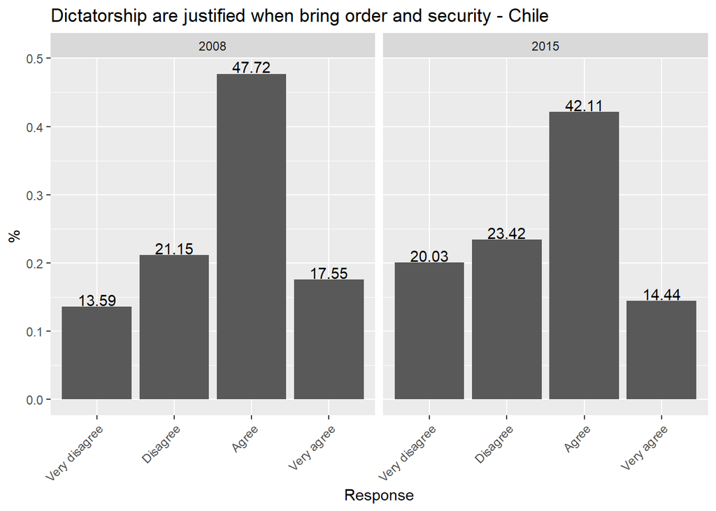

```r
# Frecuency
mergesvy <- mergeiccs %>% filter(country == "CHL") %>% as_survey_design(strata = jkzones,
    weights = totwgts, ids = jkreps, nest = TRUE)

# frequency table via taylor series linearization
table_freq_01 <- mergesvy %>% dplyr::group_by(time, dicta1) %>% summarize(proportion = survey_mean(,
    na.rm = TRUE))
# help(srvyr)



df = data.frame(table_freq_01, digits = 2)
# summary(factor(df$proportion))

df = df %>% mutate(perc = proportion * 100) %>% mutate(p = round(perc, 2)) %>%
    mutate(label = factor(dicta1, labels = c("Very disagree", "Disagree", "Agree",
        "Very agree")))

# df <- data.frame(trt = c('a', 'b', 'c', 'd'), outcome = c(0.136, 0.212,
# 0.477, 0.176), study=c(09, 09, 09, 09))
df1_chi <- df %>% mutate(country = "CHI")

order_chile = ggplot(df, aes(label, proportion)) + facet_wrap(~time) + geom_text(aes(label = p),
    position = position_dodge(0.3), vjust = -0.1) + theme(axis.text.x = element_text(angle = 45,
    hjust = 1)) + ggtitle("Dictatorship are justified when bring order and security - Chile") +
    labs(x = "Response", y = "%") + geom_col()

# Graph
print(order_chile)
```

- Dictatorship are justified when bring economic benefits

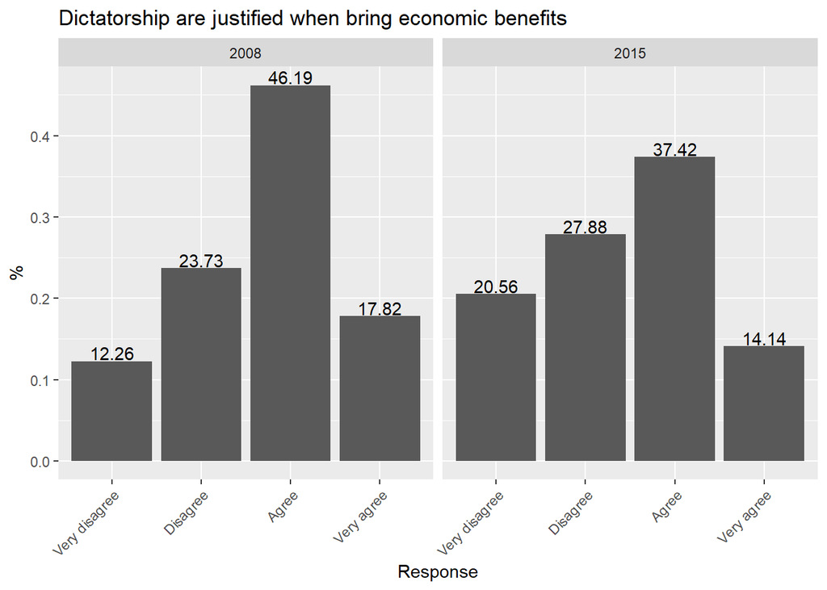

```r
mergesvy <- mergeiccs %>% filter(country == "CHL") %>% as_survey_design(strata = jkzones,
    weights = totwgts, ids = jkreps, nest = TRUE)

# frequency table via taylor series linearization
table_freq_08 <- mergesvy %>% dplyr::group_by(time, dicta2) %>% summarize(proportion = survey_mean(,
    na.rm = TRUE))
# help(srvyr)

df = data.frame(table_freq_08, digits = 2)
# summary(factor(df$proportion))

df = df %>% mutate(perc = proportion * 100) %>% mutate(p = round(perc, 2)) %>%
    mutate(label = factor(dicta2, labels = c("Very disagree", "Disagree", "Agree",
        "Very agree")))

# df <- data.frame(trt = c('a', 'b', 'c', 'd'), outcome = c(0.136, 0.212,
# 0.477, 0.176), study=c(09, 09, 09, 09))
df2_chi <- df %>% mutate(country = "CHI")

order_ch2q1 = ggplot(df, aes(label, proportion)) + facet_wrap(~time) + geom_text(aes(label = p),
    position = position_dodge(0.3), vjust = -0.1) + theme(axis.text.x = element_text(angle = 45,
    hjust = 1)) + ggtitle("Dictatorship are justified when bring economic benefits") +
    labs(x = "Response", y = "%") + geom_col()

print(order_ch2q1)
```

## México

```r
#2016
      mex16= mex16 %>%
      rename_all(tolower) %>%
      dplyr::mutate(time="2015") %>%
      dplyr::mutate (gob1= 5 - ls3g01a)%>% #invertidos
      dplyr::mutate (gob2= 5 - ls3g01b)%>%
      dplyr::mutate (gob3= 5 - ls3g01c)%>%
      dplyr::mutate (gob4= 5 - ls3g01d)%>%
      dplyr::mutate (gob5= 5 - ls3g01e)%>%
      dplyr::mutate (gob6= 5 - ls3g01f)%>%
      dplyr::mutate (dicta1= 5 - ls3g02d)%>%
      dplyr::mutate (dicta2= 5 - ls3g02e)%>%
      dplyr::select(country,totwgts, jkzones, jkreps, time, gob1, gob2, gob3, gob4, gob5, gob6, dicta1, dicta2)

#2009
mex09= mex09 %>%
      rename_all(tolower) %>%
      dplyr::mutate(time="2008") %>%
      dplyr::mutate (gob1= 5 - ls2p02a)%>% #invertidos
      dplyr::mutate (gob2= 5 - ls2p02b)%>%
      dplyr::mutate (gob3= 5 - ls2p02c)%>%
      dplyr::mutate (gob4= 5 - ls2p02d)%>%
      dplyr::mutate (gob5= 5 - ls2p02e)%>%
      dplyr::mutate (gob6= 5 - ls2p02f)%>%
      dplyr::mutate (dicta1= 5 - ls2p03d)%>%
      dplyr::mutate (dicta2= 5 - ls2p03e)%>%
      dplyr::select(country, totwgts, jkzones, jkreps, time, gob1, gob2, gob3, gob4, gob5, gob6, dicta1, dicta2)

#Merge
mergeiccs=full_join(mex16,mex09)
```

- Dictatorship are justified when bring order and security

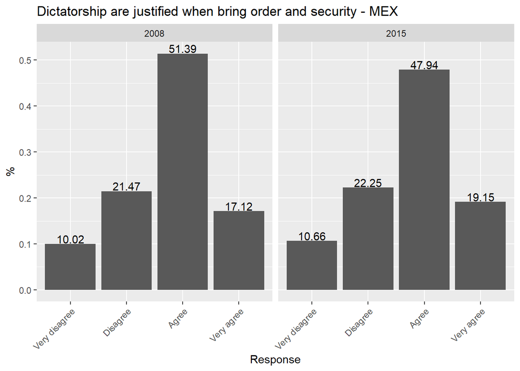

```r
mergesvy <- mergeiccs %>% filter(country == "MEX") %>% as_survey_design(strata = jkzones,
    weights = totwgts, ids = jkreps, nest = TRUE)

# frequency table via taylor series linearization
table_freq_01 <- mergesvy %>% dplyr::group_by(time, dicta1) %>% summarize(proportion = survey_mean(,
    na.rm = TRUE))
# help(srvyr)
df = data.frame(table_freq_01, digits = 2)
# summary(factor(df$proportion))

df = df %>% mutate(perc = proportion * 100) %>% mutate(p = round(perc, 2)) %>%
    mutate(label = factor(dicta1, labels = c("Very disagree", "Disagree", "Agree",
        "Very agree")))

# df <- data.frame(trt = c('a', 'b', 'c', 'd'), outcome = c(0.136, 0.212,
# 0.477, 0.176), study=c(09, 09, 09, 09))

df1_mex <- df %>% mutate(country = "MEX")

order_mexico = ggplot(df, aes(label, proportion)) + facet_wrap(~time) + geom_text(aes(label = p),
    position = position_dodge(0.3), vjust = -0.1) + theme(axis.text.x = element_text(angle = 45,
    hjust = 1)) + ggtitle("Dictatorship are justified when bring order and security - MEX") +
    labs(x = "Response", y = "%") + geom_col()

# Graph
print(order_mexico)
```

- Dictatorship are justified when bring economic benefits

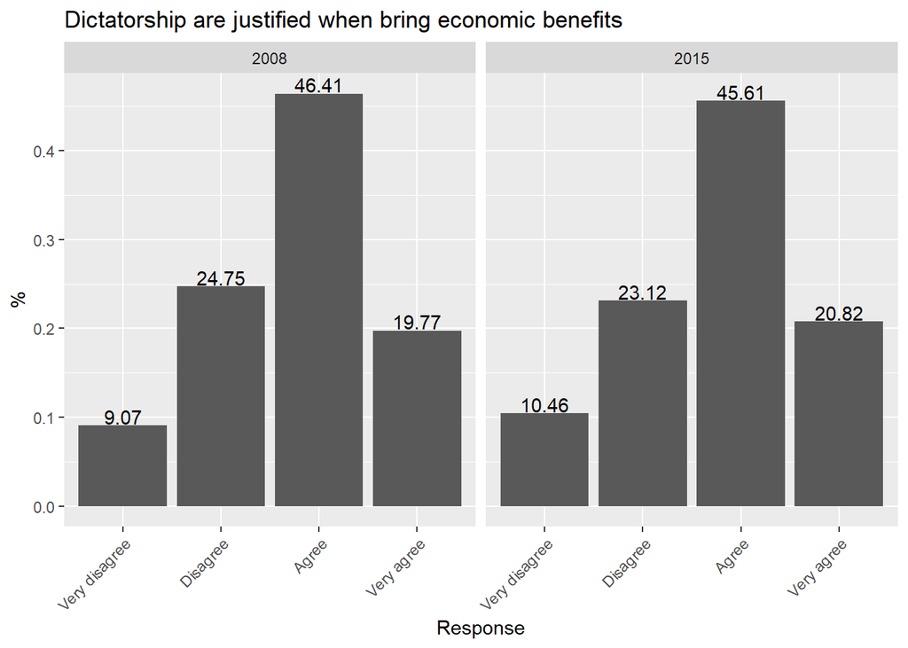

```r
mergesvy <- mergeiccs %>% filter(country == "MEX") %>% as_survey_design(strata = jkzones,
    weights = totwgts, ids = jkreps, nest = TRUE)

# frequency table via taylor series linearization
table_freq_02 <- mergesvy %>% dplyr::group_by(time, dicta2) %>% summarize(proportion = survey_mean(,
    na.rm = TRUE))
# help(srvyr)

df = data.frame(table_freq_02, digits = 2)
# summary(factor(df$proportion))

df = df %>% mutate(perc = proportion * 100) %>% mutate(p = round(perc, 2)) %>%
    mutate(label = factor(dicta2, labels = c("Very disagree", "Disagree", "Agree",
        "Very agree")))

# df <- data.frame(trt = c('a', 'b', 'c', 'd'), outcome = c(0.136, 0.212,
# 0.477, 0.176), study=c(09, 09, 09, 09))
df2_mex <- df %>% mutate(country = "MEX")
order_mex = ggplot(df, aes(label, proportion)) + facet_wrap(~time) + geom_text(aes(label = p),
    position = position_dodge(0.3), vjust = -0.1) + theme(axis.text.x = element_text(angle = 45,
    hjust = 1)) + ggtitle("Dictatorship are justified when bring economic benefits") +
    labs(x = "Response", y = "%") + geom_col()
# Graph
print(order_mex)
```

## Colombia

```r
#2016
      col16= col16 %>%
      rename_all(tolower) %>%
      dplyr::mutate(time="2015") %>%
      dplyr::mutate (gob1= 5 - ls3g01a)%>% #invertidos
      dplyr::mutate (gob2= 5 - ls3g01b)%>%
      dplyr::mutate (gob3= 5 - ls3g01c)%>%
      dplyr::mutate (gob4= 5 - ls3g01d)%>%
      dplyr::mutate (gob5= 5 - ls3g01e)%>%
      dplyr::mutate (gob6= 5 - ls3g01f)%>%
      dplyr::mutate (dicta1= 5 - ls3g02d)%>%
      dplyr::mutate (dicta2= 5 - ls3g02e)%>%
      dplyr::select(country,totwgts, jkzones, jkreps, time, gob1, gob2, gob3, gob4, gob5, gob6, dicta1, dicta2)

#2009
col09= col09 %>%
      rename_all(tolower) %>%
      dplyr::mutate(time="2008") %>%
      dplyr::mutate (gob1= 5 - ls2p02a)%>% #invertidos
      dplyr::mutate (gob2= 5 - ls2p02b)%>%
      dplyr::mutate (gob3= 5 - ls2p02c)%>%
      dplyr::mutate (gob4= 5 - ls2p02d)%>%
      dplyr::mutate (gob5= 5 - ls2p02e)%>%
      dplyr::mutate (gob6= 5 - ls2p02f)%>%
      dplyr::mutate (dicta1= 5 - ls2p03d)%>%
      dplyr::mutate (dicta2= 5 - ls2p03e)%>%
      dplyr::select(country, totwgts, jkzones, jkreps, time, gob1, gob2, gob3, gob4, gob5, gob6, dicta1, dicta2)

mergeiccs=full_join(col16,col09)
```

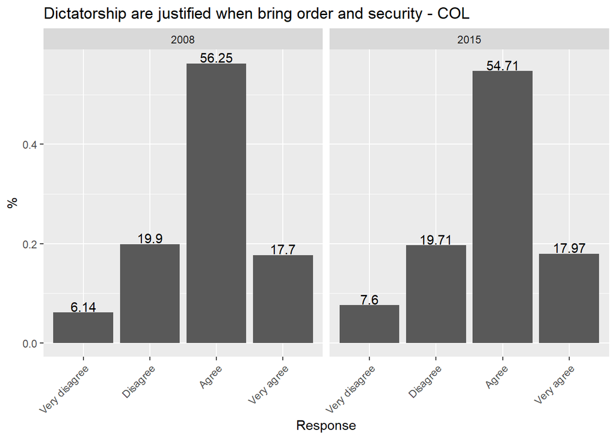

```r
mergesvy <- mergeiccs %>% filter(country == "COL") %>% as_survey_design(strata = jkzones,
    weights = totwgts, ids = jkreps, nest = TRUE)

# frequency table via taylor series linearization
table_freq_01 <- mergesvy %>% dplyr::group_by(time, dicta1) %>% summarize(proportion = survey_mean(,
    na.rm = TRUE))
# help(srvyr)

df = data.frame(table_freq_01, digits = 2)
# summary(factor(df$proportion))

df = df %>% mutate(perc = proportion * 100) %>% mutate(p = round(perc, 2)) %>%
    mutate(label = factor(dicta1, labels = c("Very disagree", "Disagree", "Agree",
        "Very agree")))

# df <- data.frame(trt = c('a', 'b', 'c', 'd'), outcome = c(0.136, 0.212,
# 0.477, 0.176), study=c(09, 09, 09, 09))
df1_col <- df %>% mutate(country = "COL")
order_colombia = ggplot(df, aes(label, proportion)) + facet_wrap(~time) + geom_text(aes(label = p),
    position = position_dodge(0.3), vjust = -0.1) + theme(axis.text.x = element_text(angle = 45,
    hjust = 1)) + ggtitle("Dictatorship are justified when bring order and security - COL") +
    labs(x = "Response", y = "%") + geom_col()
# Graph
print(order_colombia)
```

- Dictatorship are justified when bring economic benefits

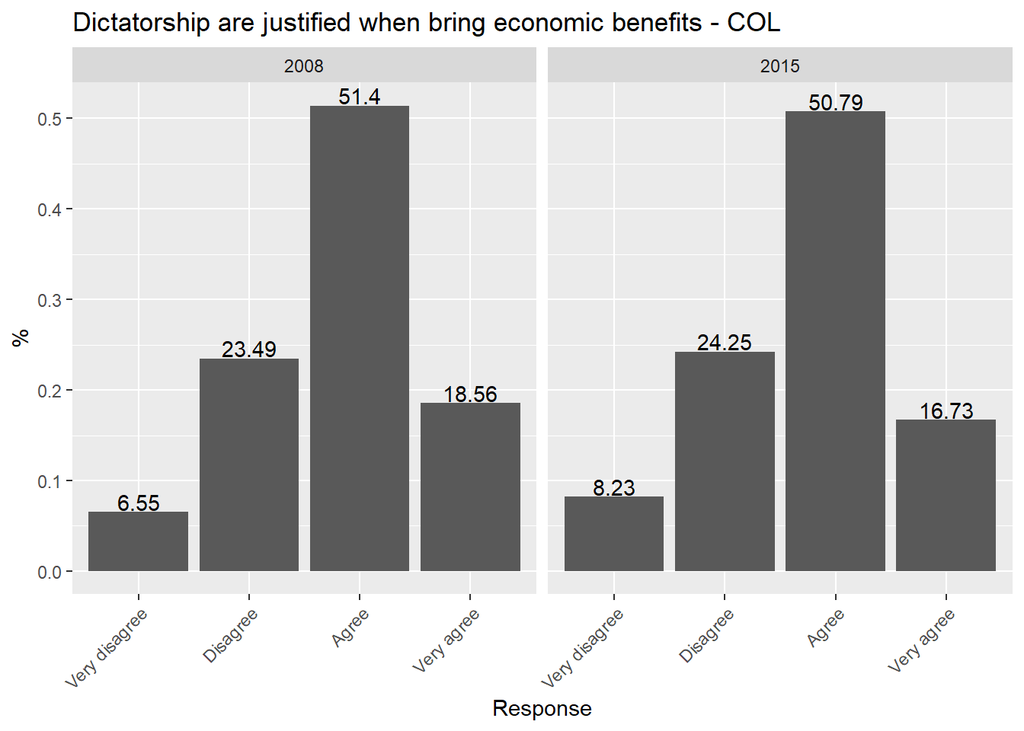

```r
mergesvy <- mergeiccs %>% filter(country == "COL") %>% as_survey_design(strata = jkzones,
    weights = totwgts, ids = jkreps, nest = TRUE)

# frequency table via taylor series linearization
table_freq_02 <- mergesvy %>% dplyr::group_by(time, dicta2) %>% summarize(proportion = survey_mean(,
    na.rm = TRUE))
# help(srvyr)

df = data.frame(table_freq_02, digits = 2)
# summary(factor(df$proportion))

df = df %>% mutate(perc = proportion * 100) %>% mutate(p = round(perc, 2)) %>%
    mutate(label = factor(dicta2, labels = c("Very disagree", "Disagree", "Agree",
        "Very agree")))

# df <- data.frame(trt = c('a', 'b', 'c', 'd'), outcome = c(0.136, 0.212,
# 0.477, 0.176), study=c(09, 09, 09, 09))
df2_col <- df %>% mutate(country = "COL")
order_colom = ggplot(df, aes(label, proportion)) + facet_wrap(~time) + geom_text(aes(label = p),
    position = position_dodge(0.3), vjust = -0.1) + theme(axis.text.x = element_text(angle = 45,
    hjust = 1)) + ggtitle("Dictatorship are justified when bring economic benefits - COL") +
    labs(x = "Response", y = "%") + geom_col()
# Graph
print(order_colom)
```

# Dominican Republic

```r
#2016
      dom16= dom16 %>%
      rename_all(tolower) %>%
      dplyr::mutate(time="2015") %>%
      dplyr::mutate (gob1= 5 - ls3g01a)%>% #invertidos
      dplyr::mutate (gob2= 5 - ls3g01b)%>%
      dplyr::mutate (gob3= 5 - ls3g01c)%>%
      dplyr::mutate (gob4= 5 - ls3g01d)%>%
      dplyr::mutate (gob5= 5 - ls3g01e)%>%
      dplyr::mutate (gob6= 5 - ls3g01f)%>%
      dplyr::mutate (dicta1= 5 - ls3g02d)%>%
      dplyr::mutate (dicta2= 5 - ls3g02e)%>%
      dplyr::select(country,totwgts, jkzones, jkreps, time, gob1, gob2, gob3, gob4, gob5, gob6, dicta1, dicta2)

#2009
      dom09= dom09 %>%
      rename_all(tolower) %>%
      dplyr::mutate(time="2008") %>%
      dplyr::mutate (gob1= 5 - ls2p02a)%>% #invertidos
      dplyr::mutate (gob2= 5 - ls2p02b)%>%
      dplyr::mutate (gob3= 5 - ls2p02c)%>%
      dplyr::mutate (gob4= 5 - ls2p02d)%>%
      dplyr::mutate (gob5= 5 - ls2p02e)%>%
      dplyr::mutate (gob6= 5 - ls2p02f)%>%
      dplyr::mutate (dicta1= 5 - ls2p03d)%>%
      dplyr::mutate (dicta2= 5 - ls2p03e)%>%
      dplyr::select(country, totwgts, jkzones, jkreps, time, gob1, gob2, gob3, gob4, gob5, gob6, dicta1, dicta2)

mergeiccs=full_join(dom16,dom09)
```

- Dictatorship are justified when bring order and security

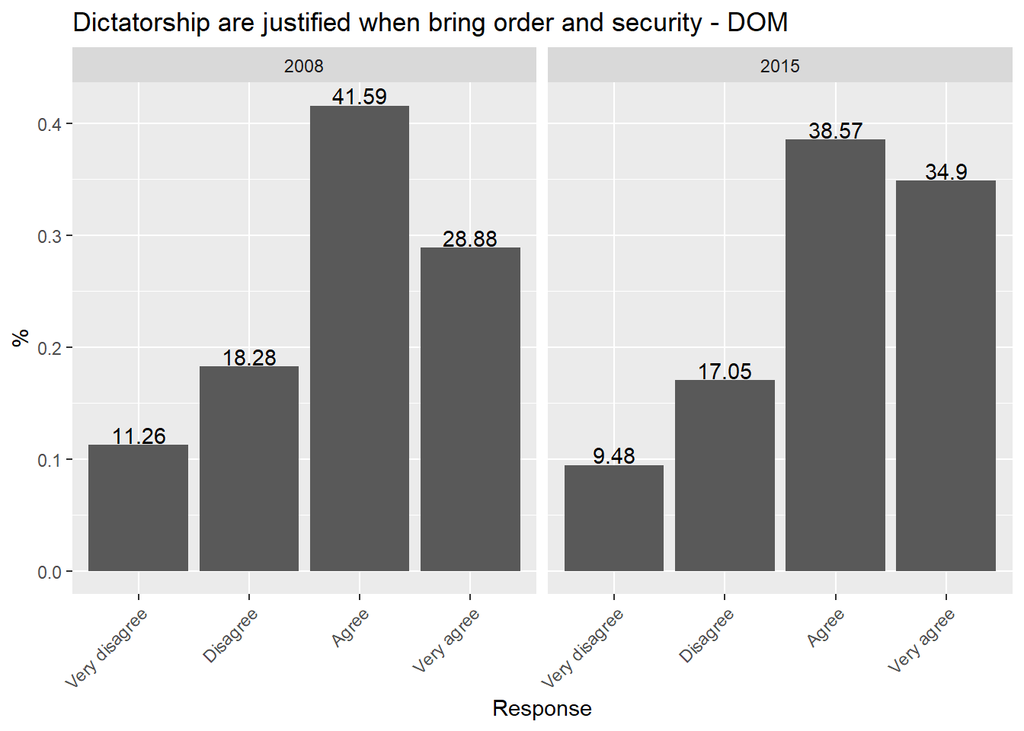

```r
mergesvy <- mergeiccs %>% filter(country == "DOM") %>% as_survey_design(strata = jkzones,
    weights = totwgts, ids = jkreps, nest = TRUE)

# frequency table via taylor series linearization
table_freq_02 <- mergesvy %>% dplyr::group_by(time, dicta1) %>% summarize(proportion = survey_mean(,
    na.rm = TRUE))
# help(srvyr)

df = data.frame(table_freq_02, digits = 2)
# summary(factor(df$proportion))

df = df %>% mutate(perc = proportion * 100) %>% mutate(p = round(perc, 2)) %>%
    mutate(label = factor(dicta1, labels = c("Very disagree", "Disagree", "Agree",
        "Very agree")))

# df <- data.frame(trt = c('a', 'b', 'c', 'd'), outcome = c(0.136, 0.212,
# 0.477, 0.176), study=c(09, 09, 09, 09))
df1_dom <- df %>% mutate(country = "DOM")
order_dominicana = ggplot(df, aes(label, proportion)) + facet_wrap(~time) +
    geom_text(aes(label = p), position = position_dodge(0.3), vjust = -0.1) +
    theme(axis.text.x = element_text(angle = 45, hjust = 1)) + ggtitle("Dictatorship are justified when bring order and security - DOM") +
    labs(x = "Response", y = "%") + geom_col()

# Graph
print(order_dominicana)
```

- Dictatorship are justified when bring economic benefits

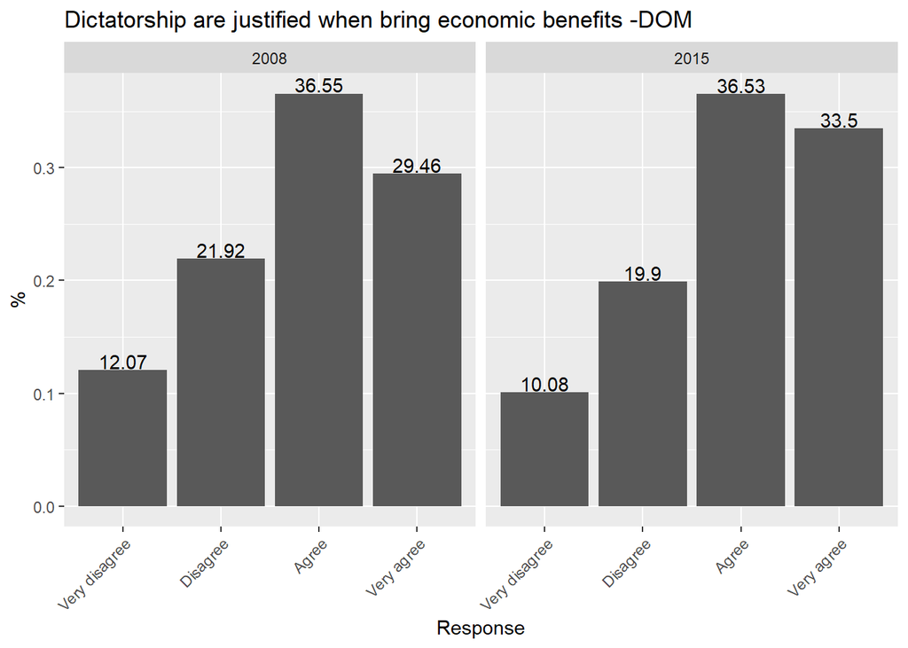

```r
mergesvy <- mergeiccs %>% filter(country == "DOM") %>% as_survey_design(strata = jkzones,
    weights = totwgts, ids = jkreps, nest = TRUE)

# frequency table via taylor series linearization
table_freq_01 <- mergesvy %>% dplyr::group_by(time, dicta2) %>% summarize(proportion = survey_mean(,
    na.rm = TRUE))
# help(srvyr)

df = data.frame(table_freq_01, digits = 2)
# summary(factor(df$proportion))

df = df %>% mutate(perc = proportion * 100) %>% mutate(p = round(perc, 2)) %>%
    mutate(label = factor(dicta2, labels = c("Very disagree", "Disagree", "Agree",
        "Very agree")))

# df <- data.frame(trt = c('a', 'b', 'c', 'd'), outcome = c(0.136, 0.212,
# 0.477, 0.176), study=c(09, 09, 09, 09))
df2_dom <- df %>% mutate(country = "DOM")
order_dom = ggplot(df, aes(label, proportion)) + facet_wrap(~time) + geom_text(aes(label = p),
    position = position_dodge(0.3), vjust = -0.1) + theme(axis.text.x = element_text(angle = 45,
    hjust = 1)) + ggtitle("Dictatorship are justified when bring economic benefits -DOM") +
    labs(x = "Response", y = "%") + geom_col()

# Graph
print(order_dom)
```

## Guatemala

```r
#2009
gtm= gtm09 %>%
      rename_all(tolower) %>%
      dplyr::mutate(time="2008") %>%
      dplyr::mutate (gob1= 5 - ls2p02a)%>% #invertidos
      dplyr::mutate (gob2= 5 - ls2p02b)%>%
      dplyr::mutate (gob3= 5 - ls2p02c)%>%
      dplyr::mutate (gob4= 5 - ls2p02d)%>%
      dplyr::mutate (gob5= 5 - ls2p02e)%>%
      dplyr::mutate (gob6= 5 - ls2p02f)%>%
      dplyr::mutate (dicta1= 5 - ls2p03d)%>%
      dplyr::mutate (dicta2= 5 - ls2p03e)%>%
      dplyr::select(country, totwgts, jkzones, jkreps, time, gob1, gob2, gob3, gob4, gob5, gob6, dicta1, dicta2)
mergeiccs=(gtm)
```

- Dictatorship are justified when bring order and security

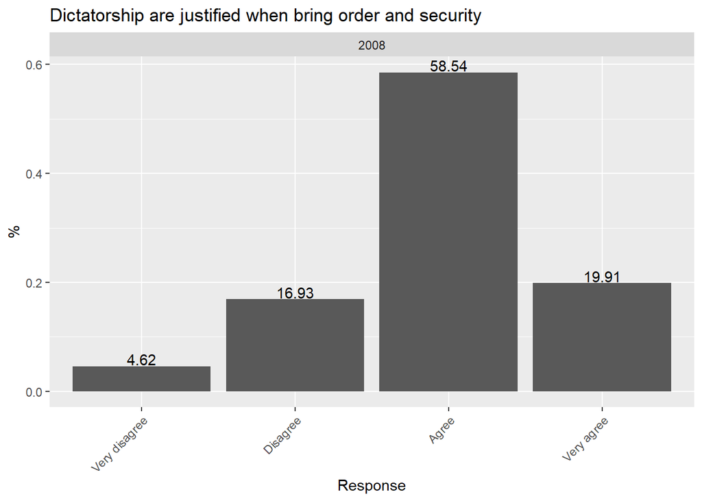

```r
mergesvy <- mergeiccs %>% filter(country == "GTM") %>% as_survey_design(strata = jkzones,
    weights = totwgts, ids = jkreps, nest = TRUE)

# frequency table via taylor series linearization
table_freq_02 <- mergesvy %>% dplyr::group_by(time, dicta1) %>% summarize(proportion = survey_mean(,
    na.rm = TRUE))
# help(srvyr)

df = data.frame(table_freq_02, digits = 2)
# summary(factor(df$proportion))

df = df %>% mutate(perc = proportion * 100) %>% mutate(p = round(perc, 2)) %>%
    mutate(label = factor(dicta1, labels = c("Very disagree", "Disagree", "Agree",
        "Very agree")))

# df <- data.frame(trt = c('a', 'b', 'c', 'd'), outcome = c(0.136, 0.212,
# 0.477, 0.176), study=c(09, 09, 09, 09))
df1_gtm <- df %>% mutate(country = "GTM")

order_guatemala = ggplot(df, aes(label, proportion)) + facet_wrap(~time) + geom_text(aes(label = p),
    position = position_dodge(0.3), vjust = -0.1) + theme(axis.text.x = element_text(angle = 45,
    hjust = 1)) + ggtitle("Dictatorship are justified when bring order and security") +
    labs(x = "Response", y = "%") + geom_col()

# Graph
print(order_guatemala)
```

- Dictatorship are justified when bring economic benefits

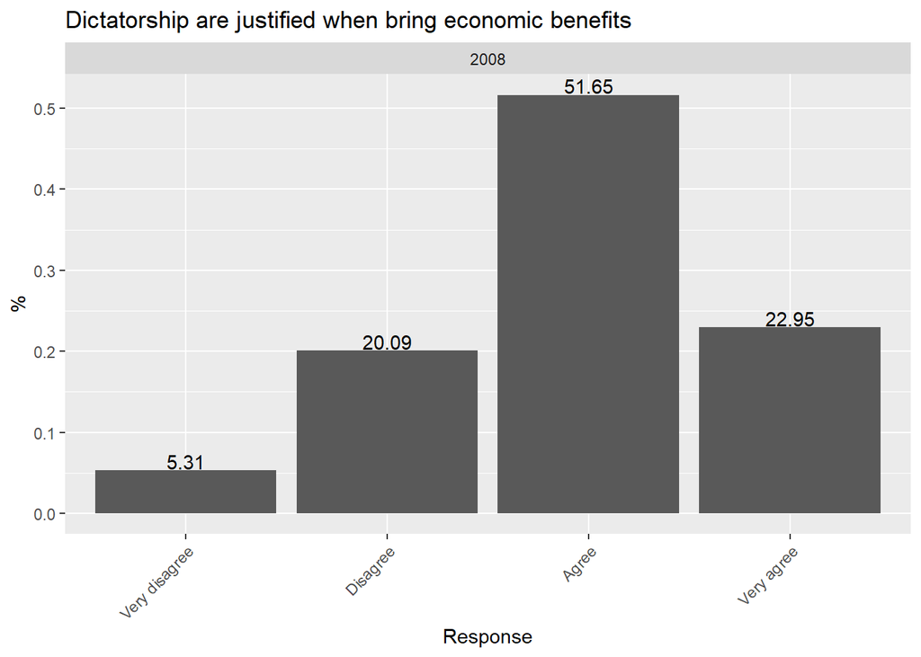

```r
mergesvy <- mergeiccs %>% filter(country == "GTM") %>% as_survey_design(strata = jkzones,
    weights = totwgts, ids = jkreps, nest = TRUE)

# frequency table via taylor series linearization
table_freq_02 <- mergesvy %>% dplyr::group_by(time, dicta2) %>% summarize(proportion = survey_mean(,
    na.rm = TRUE))
# help(srvyr)

df = data.frame(table_freq_02, digits = 2)
# summary(factor(df$proportion))

df = df %>% mutate(perc = proportion * 100) %>% mutate(p = round(perc, 2)) %>%
    mutate(label = factor(dicta2, labels = c("Very disagree", "Disagree", "Agree",
        "Very agree")))

# df <- data.frame(trt = c('a', 'b', 'c', 'd'), outcome = c(0.136, 0.212,
# 0.477, 0.176), study=c(09, 09, 09, 09))
df2_gtm <- df %>% mutate(country = "GTM")

order_guatemala = ggplot(df, aes(label, proportion)) + facet_wrap(~time) + geom_text(aes(label = p),
    position = position_dodge(0.3), vjust = -0.1) + theme(axis.text.x = element_text(angle = 45,
    hjust = 1)) + ggtitle("Dictatorship are justified when bring economic benefits") +
    labs(x = "Response", y = "%") + geom_col()

# Graph
print(order_guatemala)
```

## Perú

```r
#2016
      per= per16 %>%
      rename_all(tolower) %>%
      dplyr::mutate(time="2015") %>%
      dplyr::mutate (gob1= 5 - ls3g01a)%>% #invertidos
      dplyr::mutate (gob2= 5 - ls3g01b)%>%
      dplyr::mutate (gob3= 5 - ls3g01c)%>%
      dplyr::mutate (gob4= 5 - ls3g01d)%>%
      dplyr::mutate (gob5= 5 - ls3g01e)%>%
      dplyr::mutate (gob6= 5 - ls3g01f)%>%
      dplyr::mutate (dicta1= 5 - ls3g02d)%>%
      dplyr::mutate (dicta2= 5 - ls3g02e)%>%
      dplyr::select(country,totwgts, jkzones, jkreps, time, gob1, gob2, gob3, gob4, gob5, gob6, dicta1, dicta2)
mergeiccs=(per)
```

- Dictatorship are justified when bring order and security

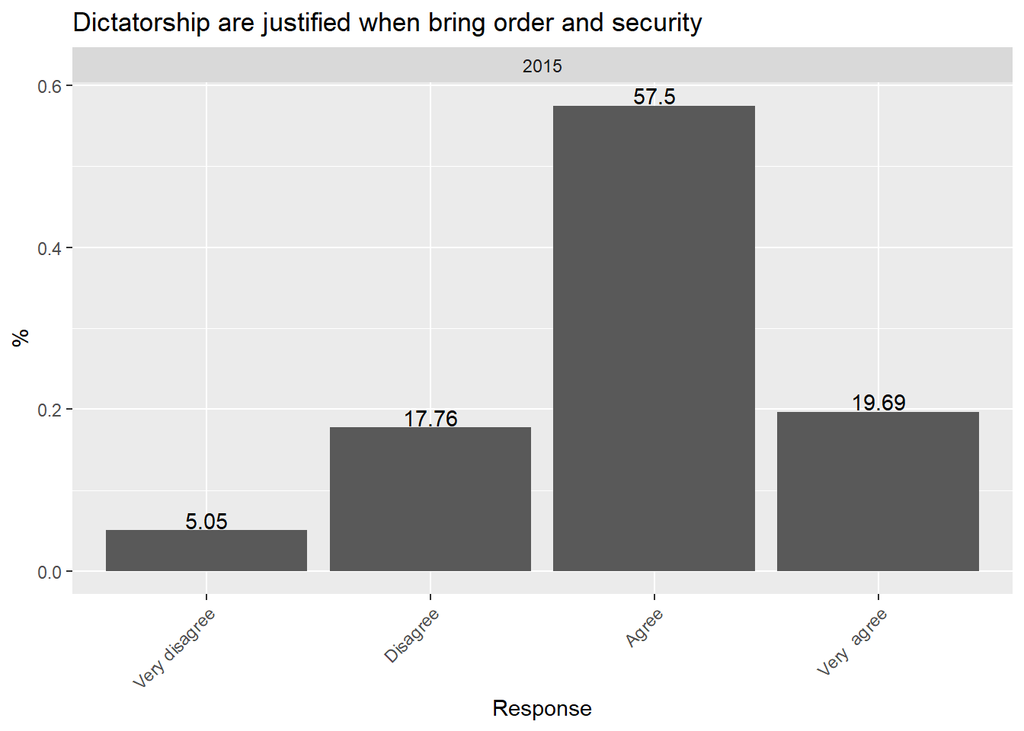

```r
mergesvy <- mergeiccs %>% filter(country == "PER") %>% as_survey_design(strata = jkzones,
    weights = totwgts, ids = jkreps, nest = TRUE)

# frequency table via taylor series linearization
table_freq_02 <- mergesvy %>% dplyr::group_by(time, dicta1) %>% summarize(proportion = survey_mean(,
    na.rm = TRUE))
# help(srvyr)

df = data.frame(table_freq_02, digits = 2)
# summary(factor(df$proportion))

df = df %>% mutate(perc = proportion * 100) %>% mutate(p = round(perc, 2)) %>%
    mutate(label = factor(dicta1, labels = c("Very disagree", "Disagree", "Agree",
        "Very  agree")))

# df <- data.frame(trt = c('a', 'b', 'c', 'd'), outcome = c(0.136, 0.212,
# 0.477, 0.176), study=c(09, 09, 09, 09))
df1_per <- df %>% mutate(country = "PER")
order_per = ggplot(df, aes(label, proportion)) + facet_wrap(~time) + geom_text(aes(label = p),
    position = position_dodge(0.3), vjust = -0.1) + theme(axis.text.x = element_text(angle = 45,
    hjust = 1)) + ggtitle("Dictatorship are justified when bring order and security") +
    labs(x = "Response", y = "%") + geom_col()

# Graph
print(order_per)
```

- Dictatorship are justified when bring economic benefits

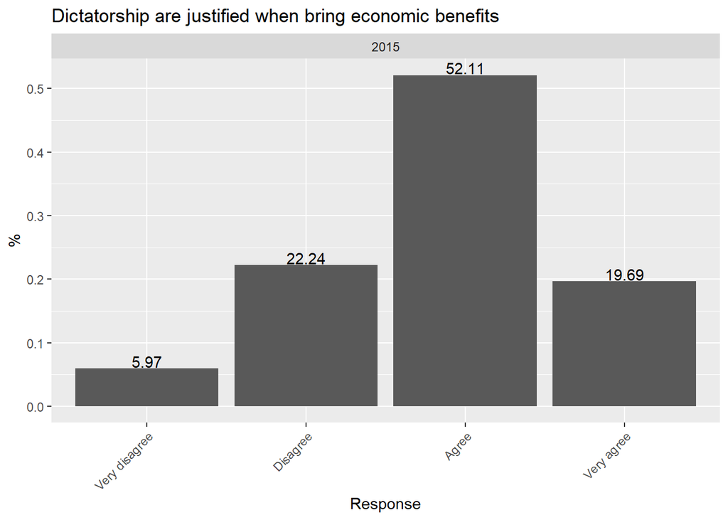

```r
mergesvy <- mergeiccs %>% filter(country == "PER") %>% as_survey_design(strata = jkzones,
    weights = totwgts, ids = jkreps, nest = TRUE)

# frequency table via taylor series linearization
table_freq_02 <- mergesvy %>% dplyr::group_by(time, dicta2) %>% summarize(proportion = survey_mean(,
    na.rm = TRUE))
# help(srvyr)

df = data.frame(table_freq_02, digits = 2)
# summary(factor(df$proportion))

df = df %>% mutate(perc = proportion * 100) %>% mutate(p = round(perc, 2)) %>%
    mutate(label = factor(dicta2, labels = c("Very disagree", "Disagree", "Agree",
        "Very agree")))

# df <- data.frame(trt = c('a', 'b', 'c', 'd'), outcome = c(0.136, 0.212,
# 0.477, 0.176), study=c(09, 09, 09, 09))
df2_per <- df %>% mutate(country = "PER")
order_per = ggplot(df, aes(label, proportion)) + facet_wrap(~time) + geom_text(aes(label = p),
    position = position_dodge(0.3), vjust = -0.1) + theme(axis.text.x = element_text(angle = 45,
    hjust = 1)) + ggtitle("Dictatorship are justified when bring economic benefits") +
    labs(x = "Response", y = "%") + geom_col()

# Graph
print(order_per)
```

## Paraguay

```r
pry= pry09 %>%
 rename_all(tolower) %>%
      dplyr::mutate(time="2008") %>%
      dplyr::mutate (gob1= 5 - ls2p02a)%>% #invertidos
      dplyr::mutate (gob2= 5 - ls2p02b)%>%
      dplyr::mutate (gob3= 5 - ls2p02c)%>%
      dplyr::mutate (gob4= 5 - ls2p02d)%>%
      dplyr::mutate (gob5= 5 - ls2p02e)%>%
      dplyr::mutate (gob6= 5 - ls2p02f)%>%
      dplyr::mutate (dicta1= 5 - ls2p03d)%>%
      dplyr::mutate (dicta2= 5 - ls2p03e)%>%
      dplyr::select(country, totwgts, jkzones, jkreps, time, gob1, gob2, gob3, gob4, gob5, gob6, dicta1, dicta2)

mergeiccs=(pry)
```

- Dictatorship are justified when bring order and security

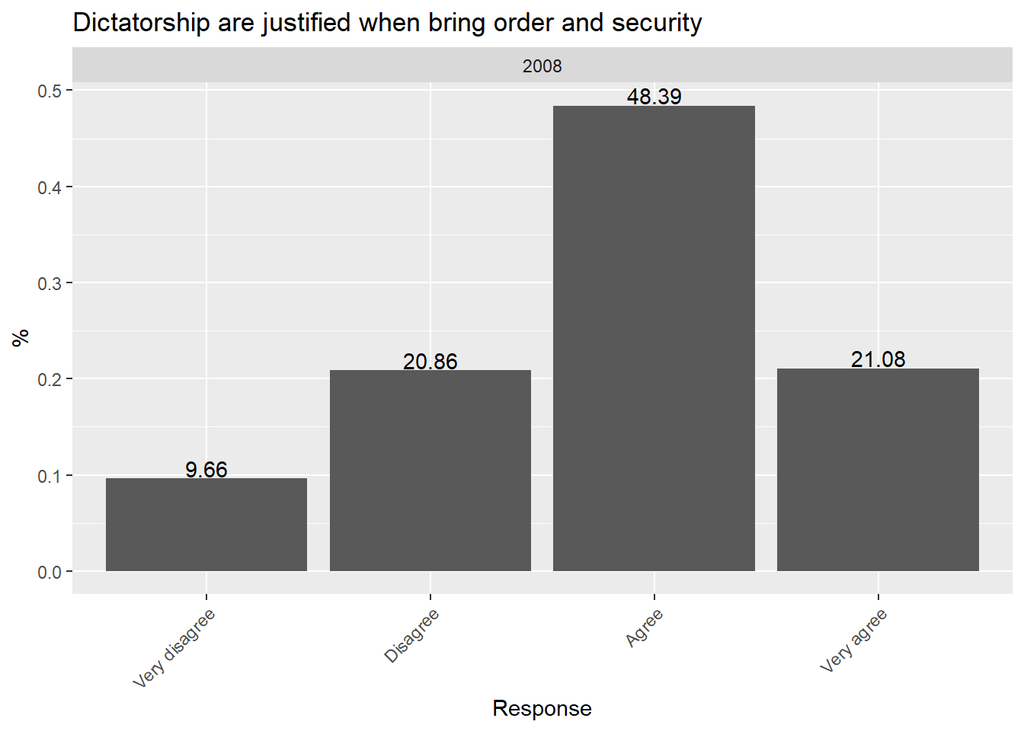

```r
mergesvy <- mergeiccs %>% filter(country == "PRY") %>% as_survey_design(strata = jkzones,
    weights = totwgts, ids = jkreps, nest = TRUE)

# frequency table via taylor series linearization
table_freq_02 <- mergesvy %>% dplyr::group_by(time, dicta1) %>% summarize(proportion = survey_mean(,
    na.rm = TRUE))
# help(srvyr)

df = data.frame(table_freq_02, digits = 2)
# summary(factor(df$proportion))

df = df %>% mutate(perc = proportion * 100) %>% mutate(p = round(perc, 2)) %>%
    mutate(label = factor(dicta1, labels = c("Very disagree", "Disagree", "Agree",
        "Very agree")))

# df <- data.frame(trt = c('a', 'b', 'c', 'd'), outcome = c(0.136, 0.212,
# 0.477, 0.176), study=c(09, 09, 09, 09))
df1_pry <- df %>% mutate(country = "PRY")
order_pry = ggplot(df, aes(label, proportion)) + facet_wrap(~time) + geom_text(aes(label = p),
    position = position_dodge(0.3), vjust = -0.1) + theme(axis.text.x = element_text(angle = 45,
    hjust = 1)) + ggtitle("Dictatorship are justified when bring order and security") +
    labs(x = "Response", y = "%") + geom_col()

# Graph
print(order_pry)
```

- Dictatorship are justified when bring economic benefits

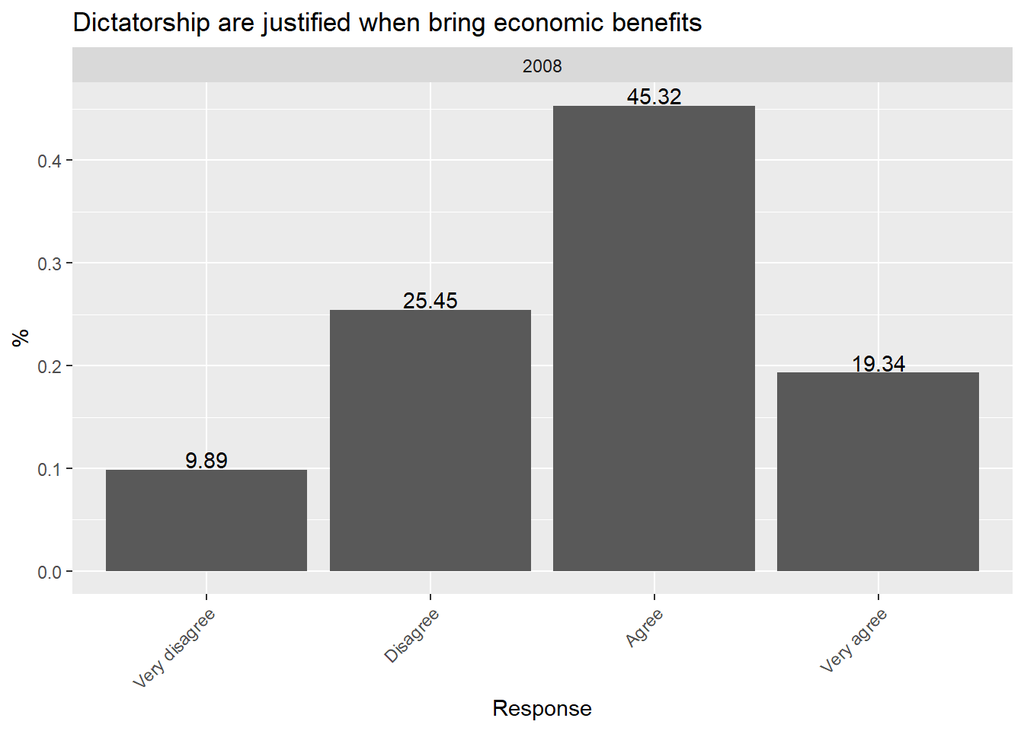

```r
mergesvy <- mergeiccs %>% filter(country == "PRY") %>% as_survey_design(strata = jkzones,
    weights = totwgts, ids = jkreps, nest = TRUE)

# frequency table via taylor series linearization
table_freq_02 <- mergesvy %>% dplyr::group_by(time, dicta2) %>% summarize(proportion = survey_mean(,
    na.rm = TRUE))
# help(srvyr)
df = data.frame(table_freq_02, digits = 2)
# summary(factor(df$proportion))

df = df %>% mutate(perc = proportion * 100) %>% mutate(p = round(perc, 2)) %>%
    mutate(label = factor(dicta2, labels = c("Very disagree", "Disagree", "Agree",
        "Very agree")))

df2_pry <- df %>% mutate(country = "PRY")
order_pry = ggplot(df, aes(label, proportion)) + facet_wrap(~time) + geom_text(aes(label = p),
    position = position_dodge(0.3), vjust = -0.1) + theme(axis.text.x = element_text(angle = 45,
    hjust = 1)) + ggtitle("Dictatorship are justified when bring economic benefits") +
    labs(x = "Response", y = "%") + geom_col()

# Graph
print(order_pry)
```

# All Latinamerica Countries

## Change in support for dictatorship

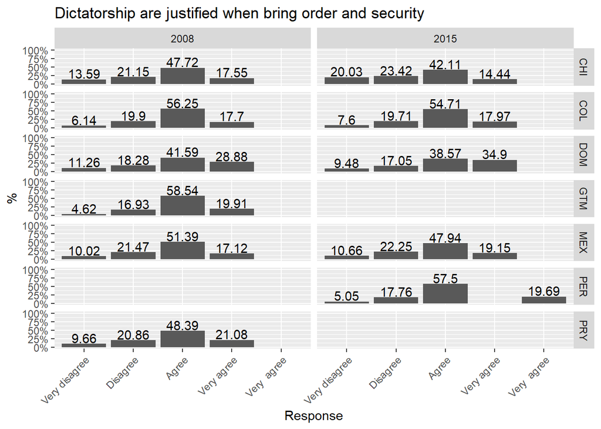

```r
df1 <- rbind(df1_chi, df1_mex, df1_col, df1_dom, df1_per, df1_pry, df1_gtm)

ggplot(df1 , aes(label, proportion)) +
        facet_grid(country ~ time) +
         geom_text(aes(label = p), position = position_dodge(0.3), vjust=-0.1)+
scale_y_continuous(labels = scales::percent, limits = c(0,1)) +
        theme(axis.text.x = element_text(angle =45, hjust = 1)) +
         ggtitle("Dictatorship are justified when bring order and security") +
        labs(x = "Response", y = "%") +
        geom_col()
```

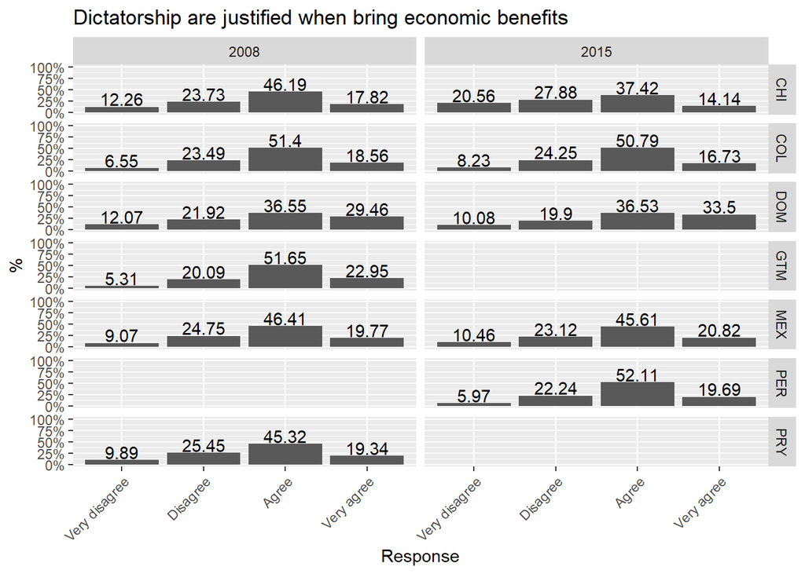

```r
df2 <- rbind(df2_chi, df2_mex, df2_col, df2_dom, df2_per, df2_pry, df2_gtm)

ggplot(df2 , aes(label, proportion)) +
        facet_grid(country ~ time) +
         geom_text(aes(label = p), position = position_dodge(0.3), vjust=-0.1)+
 scale_y_continuous(labels = scales::percent, limits = c(0,1)) +
        theme(axis.text.x = element_text(angle =45, hjust = 1)) +
         ggtitle("Dictatorship are justified when bring economic benefits") +
        labs(x = "Response", y = "%") +
        geom_col()
```

## Change in support for dictatorship (DUMMY)

- Dictatorships are justified when they bring order and security 2009-2016: LS2P03D - LS3G02D (DUMMY)

```r
library(purrr)

aux09_i <- c("chi09", "mex09", "col09", "dom09","gtm", "pry","")
aux16_i <- c("chi16", "mex16", "col16", "dom16", "", "","per")
pais0_i <- c("CHL","MEX","COL","DOM","GTM","PRY","PER")
pais_i  <- c("CHI","MEX","COL","DOM","GTM","PRY","PER")

df_final <- NULL

for(i in 1:7){

if(aux09_i[i]!="") {aux09 <- get(aux09_i[i])}
if(aux16_i[i]!="") {aux16 <- get(aux16_i[i])}
pais0 = pais0_i[i]
pais = pais_i[i]

aux09 <- aux09 %>%
  mutate(dicta1 = case_when(
    dicta1 %in% c(1,2) ~ 1,
    dicta1 %in% c(3,4) ~ 2,
    is.na(dicta1) ~ dicta1,
    TRUE ~ 0
  )) %>%
  mutate(dicta2 = case_when(
    dicta2 %in% c(1,2) ~ 1,
    dicta2 %in% c(3,4) ~ 2,
    is.na(dicta2) ~ dicta2,
    TRUE ~ 0
  ))
aux16 <- aux16 %>%
  mutate(dicta1 = case_when(
    dicta1 %in% c(1,2) ~ 1,
    dicta1 %in% c(3,4) ~ 2,
    is.na(dicta1) ~ dicta1,
    TRUE ~ 0
  )) %>%
  mutate(dicta2 = case_when(
    dicta2 %in% c(1,2) ~ 1,
    dicta2 %in% c(3,4) ~ 2,
    is.na(dicta2) ~ dicta2,
    TRUE ~ 0
  ))

if(aux09_i[i]!="" & aux16_i[i]!=""){ mergeiccs=full_join(aux16, aux09) }
if(aux09_i[i]!="" & aux16_i[i]==""){ mergeiccs= aux09 }
if(aux09_i[i]=="" & aux16_i[i]!=""){ mergeiccs= aux16 }

mergesvy <-  mergeiccs %>%
      filter(country==pais0) %>%
      as_survey_design(
      strata = jkzones,
      weights = totwgts,
      ids = jkreps,
      nest = TRUE)

# frequency table via taylor series linearization
  table_freq_01 <- mergesvy %>%
    dplyr::group_by(time, dicta1) %>%
    summarize(proportion = survey_mean(,na.rm=TRUE))
  #help(srvyr)

  df = data.frame(table_freq_01, digits=2)

  df= df %>%
    mutate(perc = proportion * 100) %>%
    mutate(p=round(perc, 2)) %>%
    mutate(label=factor(dicta1, labels=c("Disagree", "Agree"))) %>%
    mutate(country=pais)

  df1_aux <- df

  df_final <- rbind(df_final, df1_aux)

}
```

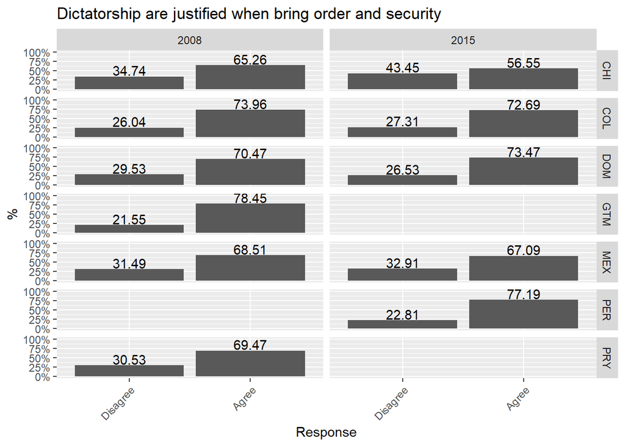

```r
ggplot(df_final , aes(label, proportion)) +
        facet_grid(country ~ time) +
         geom_text(aes(label = p), position = position_dodge(0.3), vjust=-0.1)+
 scale_y_continuous(labels = scales::percent, limits = c(0,1)) +
        theme(axis.text.x = element_text(angle =45, hjust = 1)) +
         ggtitle("Dictatorship are justified when bring order and security") +
        labs(x = "Response", y = "%") +
        geom_col()
```

```r
aux09_i <- c("chi09", "mex09", "col09", "dom09","gtm", "pry","")
aux16_i <- c("chi16", "mex16", "col16", "dom16", "", "","per")
pais0_i <- c("CHL","MEX","COL","DOM","GTM","PRY","PER")
pais_i  <- c("CHI","MEX","COL","DOM","GTM","PRY","PER")

df_final <- NULL

for(i in 1:7){

if(aux09_i[i]!="") {aux09 <- get(aux09_i[i])}
if(aux16_i[i]!="") {aux16 <- get(aux16_i[i])}
pais0 = pais0_i[i]
pais = pais_i[i]

aux09 <- aux09 %>%
  mutate(dicta1 = case_when(
    dicta1 %in% c(1,2) ~ 1,
    dicta1 %in% c(3,4) ~ 2,
    is.na(dicta1) ~ dicta1,
    TRUE ~ 0
  )) %>%
  mutate(dicta2 = case_when(
    dicta2 %in% c(1,2) ~ 1,
    dicta2 %in% c(3,4) ~ 2,
    is.na(dicta2) ~ dicta2,
    TRUE ~ 0
  ))
aux16 <- aux16 %>%
  mutate(dicta1 = case_when(
    dicta1 %in% c(1,2) ~ 1,
    dicta1 %in% c(3,4) ~ 2,
    is.na(dicta1) ~ dicta1,
    TRUE ~ 0
  )) %>%
  mutate(dicta2 = case_when(
    dicta2 %in% c(1,2) ~ 1,
    dicta2 %in% c(3,4) ~ 2,
    is.na(dicta2) ~ dicta2,
    TRUE ~ 0
  ))

if(aux09_i[i]!="" & aux16_i[i]!=""){ mergeiccs=full_join(aux16, aux09) }
if(aux09_i[i]!="" & aux16_i[i]==""){ mergeiccs= aux09 }
if(aux09_i[i]=="" & aux16_i[i]!=""){ mergeiccs= aux16 }

mergesvy <-  mergeiccs %>%
      filter(country==pais0) %>%
      as_survey_design(
      strata = jkzones,
      weights = totwgts,
      ids = jkreps,
      nest = TRUE)

# frequency table via taylor series linearization
  table_freq_01 <- mergesvy %>%
    dplyr::group_by(time, dicta2) %>%
    summarize(proportion = survey_mean(,na.rm=TRUE))
  #help(srvyr)

  df = data.frame(table_freq_01, digits=2)

  df= df %>%
    mutate(perc = proportion * 100) %>%
    mutate(p=round(perc, 2)) %>%
    mutate(label=factor(dicta2, labels=c("Disagree", "Agree"))) %>%
    mutate(country=pais)

  df1_aux <- df

  df_final <- rbind(df_final, df1_aux)

}
```

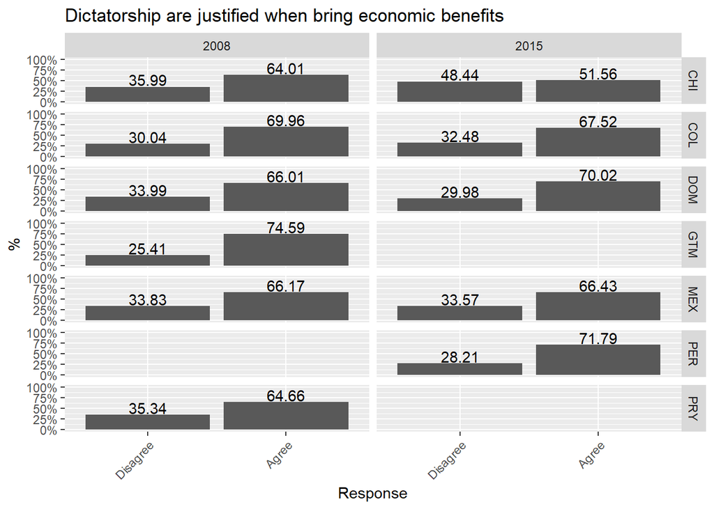

```r
ggplot(df_final , aes(label, proportion)) +
        facet_grid(country ~ time) +
         geom_text(aes(label = p), position = position_dodge(0.3), vjust=-0.1)+
  scale_y_continuous(labels = scales::percent, limits = c(0,1)) +
        theme(axis.text.x = element_text(angle =45, hjust = 1)) +
         ggtitle("Dictatorship are justified when bring economic benefits") +
        labs(x = "Response", y = "%") +
        geom_col()
```

# Sample

- All observations

```r
#Data frames with all variables
#2009
dict09 =  iccs09 %>%
  mutate(time          = 2008) %>%
  mutate(country       = COUNTRY) %>%
  mutate(idcountry     = IDCNTRY) %>%
  mutate(idschool       = IDSCHOOL) %>%
  mutate(idstudent     = IDSTUD) %>%
  mutate(idstudent = (time*1000000000000 + idcountry*100000000 + idstudent)) %>% #NEW IDSTUDENT
  mutate(dict_safety   = 5-LS2P03D) %>% #DICTATORSHIPS ARE JUSTIFIED WHEN THEY BRING ORDER AND SAFETY
  mutate(dict_benefits = 5-LS2P03E) %>% #DICTATORSHIPS ARE JUSTIFIED WHEN THEY BRING ECONOMIC BENEFITS
  mutate(dict          = (dict_safety + dict_benefits)/2) %>% #MEAN DIC
  mutate(pv1civ        = PV1CIV) %>%
  mutate(pv2civ        = PV2CIV) %>%
  mutate(pv3civ        = PV3CIV) %>%
  mutate(pv4civ        = PV4CIV) %>%
  mutate(pv5civ        = PV5CIV) %>%
  mutate(civic_knowledge = (pv1civ + pv2civ + pv3civ + pv4civ + pv5civ)/5) %>% #MEAN CIVIC KNOWLEDGE
  mutate(s_intrust       = INTRUST) %>% #TRUST IN CIVIC INSTITUTIONS
  mutate(s_opdisc        = OPDISC) %>%  #OPENNESS IN CLASS DISCUSSION
  mutate(s_hisced        = HISCED) %>%  #HIGHEST PARENTAL EDUCATIONAL LEVEL
  mutate(univ            = ifelse(s_hisced>3, 1, 0)) %>% #UNIVERSITARY PARENTS
  mutate(s_hisei         = HISEI) %>%   #PARENT'S HIGHEST OCCUPATIONAL STATUS
  mutate(s_homelit       = HOMELIT) %>% #HOME LITERACY
  mutate(s_gender        = SGENDER) %>% #GENDER OF STUDENT
  mutate(s_citcon        = CITCON) %>%  #CONVENTIONAL CITIZENSHIP
  mutate(s_citsoc        = CITSOC) %>%  #SOCIAL MOVEMENT REL. CITIZENSHIP
  mutate(s_citeff        = CITEFF) %>%  #CITIZENSHIP SELF-EFFICACY
  mutate(s_cntatt        = ATTCNT) %>%  #ATTITUDES TOWARDS OWN COUNTRY
  mutate(s_geneql        = GENEQL) %>%  #ATTITUDES TOWARDS GENDER EQUALITY
  mutate(s_ethrght       = ETHRGHT) %>% #EQUAL RIGHTS FOR ALL ETHNIC GROUPS
  mutate(l_attviol       = ATTVIOL) %>% #ATTITUDES: USE OF VIOLENCE
  mutate(l_attdiv        = ATTDIFF) %>% #ATTITUDES: NEIGHBOURHOOD DIVERSITY
  mutate(l_autgov        = AUTGOV) %>%  #AUTHORITARIANISM IN GOVERNMENT
  mutate(l_attcorr       = ATTCORR) %>% #CORRUPT PRACTICES IN GOVERNMENT
  mutate(l_dislaw        = DISLAW) %>%  #ATTITUDES: DISOBEYING THE LAW
  mutate(l_empclas       = EMPATH) %>%  #EMPATHY TOWARDS CLASSMATES
  mutate(s_poldisc       = POLDISC) %>% #DISCUSSION OF POL. AND SOC. ISSUES
  #TRUST
  mutate(nac_gob       = 5 - IS2P27A) %>% #TRUST INSTITUTIONS-NATIONAL GOVERNMENT
  mutate(local_gob     = 5 - IS2P27B) %>% #TRUST INSTITUTIONS-LOCAL GOVERNMENT
  mutate(courts        = 5 - IS2P27C) %>% #TRUST INSTITUTIONS-COURTS
  mutate(police        = 5 - IS2P27D) %>% #TRUST INSTITUTIONS-POLICE
  mutate(pol_parties   = 5 - IS2P27E) %>% #TRUST INSTITUTIONS-POLITICAL PARTIES
  mutate(parliament    = 5 - IS2P27F) %>% #TRUST INSTITUTIONS-PARLIAMENT
  mutate(media         = 5 - IS2P27G) %>% #TRUST INSTITUTIONS-MEDIA
  mutate(ffaa          = 5 - IS2P27H) %>% #TRUST INSTITUTIONS-FFAA
  mutate(school        = 5 - IS2P27I) %>% #TRUST INSTITUTIONS-SCHOOL
  mutate(unit_nations  = 5 - IS2P27J) %>% #TRUST INSTITUTIONS-UNITED NATIONS
  mutate(people        = 5 - IS2P27K) %>% #TRUST INSTITUTIONS-PEOPLE
  #WEITHINGS5 -
  mutate(totwgts       = TOTWGTS) %>%   #FINAL STUDENT WEIGHT
  mutate(wgtfac1       = WGTFAC1) %>%   #SCHOOL BASE WEIGHT
  mutate(wgtadj1s      = WGTADJ1S) %>%  #SCHOOL WEIGHT ADJUSTMENT-STUDENT STUDY
  mutate(wgtfac2s      = WGTFAC2S) %>%  #CLASS WEIGHT FACTOR
  mutate(wgtadj2s      = WGTADJ2S) %>%  #CLASS WEIGHT ADJUSTMENT
  mutate(wgtadj3s      = WGTADJ3S) %>%  #STUDENT WEIGHT ADJUSTMENT
  mutate(jkzones       = JKZONES) %>%   #JACKKNIFE ZONE - STUDENT STUDY
  mutate(jkreps        = JKREPS)  %>%  #JACKKNIFE REPLICATE CODE
  select(411:463)

#2016
dict16 = iccs16 %>%
  mutate(time            = 2015) %>%
  mutate(country         = COUNTRY) %>%
  mutate(idcountry       = IDCNTRY) %>%
  mutate(idschool        = IDSCHOOL) %>%
  mutate(idstudent       = IDSTUD) %>%
  mutate(idstudent       = (time*100000000000 + idcountry*100000000 + idstudent)) %>% #NEW IDSTUDENT
  mutate(dict_safety     = 5-LS3G02D) %>% #DICTATORSHIPS ARE JUSTIFIED WHEN THEY BRING ORDER AND SAFETY
  mutate(dict_benefits   = 5-LS3G02E) %>% #DICTATORSHIPS ARE JUSTIFIED WHEN THEY BRING ECONOMIC BENEFITS
  mutate(dict          = (dict_safety + dict_benefits)/2) %>%
  mutate(pv1civ          = PV1CIV) %>%
  mutate(pv2civ          = PV2CIV) %>%
  mutate(pv3civ          = PV3CIV) %>%
  mutate(pv4civ          = PV4CIV) %>%
  mutate(pv5civ          = PV5CIV) %>%
  mutate(civic_knowledge = (pv1civ + pv2civ + pv3civ + pv4civ + pv5civ)/5) %>% #MEAN CIVIC KNOWLEDGE
  mutate(s_intrust       = S_INTRUST) %>% #TRUST IN CIVIC INSTITUTIONS
  mutate(s_opdisc        = S_OPDISC) %>%  #OPENNESS IN CLASS DISCUSSION
  mutate(s_hisced        = S_HISCED) %>%  #HIGHEST PARENTAL EDUCATIONAL LEVEL
  mutate(univ            = ifelse(s_hisced>3, 1, 0)) %>% #UNIVERSITARY PARENTS
  mutate(s_hisei         = S_HISEI) %>%   #PARENT'S HIGHEST OCCUPATIONAL STATUS
  mutate(s_homelit       = S_HOMLIT) %>%  #HOME LITERACY
  mutate(s_gender        = S_GENDER) %>%  #GENDER OF STUDENT
  mutate(s_citcon        = S_CITCON) %>%  #CONVENTIONAL CITIZENSHIP
  mutate(s_citsoc        = S_CITSOC) %>%  #SOCIAL MOVEMENT REL. CITIZENSHIP
  mutate(s_citeff        = S_CITEFF) %>%  #CITIZENSHIP SELF-EFFICACY
  mutate(s_cntatt        = S_CNTATT) %>%  #ATTITUDES TOWARDS OWN COUNTRY
  mutate(s_geneql        = S_GENEQL) %>%  #ATTITUDES TOWARDS GENDER EQUALITY
  mutate(s_ethrght       = S_ETHRGHT) %>% #EQUAL RIGHTS FOR ALL ETHNIC GROUPS
  mutate(l_attviol       = L_ATTVIOL) %>% #ATTITUDES: USE OF VIOLENCE
  mutate(l_attdiv        = L_ATTDIV) %>%  #ATTITUDES: NEIGHBOURHOOD DIVERSITY
  mutate(l_autgov        = L_AUTGOV) %>%  #AUTHORITARIANISM IN GOVERNMENT
  mutate(l_attcorr       = L_ATTCORR) %>% #CORRUPT PRACTICES IN GOVERNMENT
  mutate(l_dislaw        = L_DISLAW) %>%  #ATTITUDES: DISOBEYING THE LAW
  mutate(l_empclas       = L_EMPCLAS) %>% #EMPATHY TOWARDS CLASSMATES
  mutate(s_poldisc       = S_POLDISC) %>% #DISCUSSION OF POL. AND SOC. ISSUES
  #TRUST
  mutate(nac_gob         = 5 - IS3G26A) %>%   #TRUST INSTITUTIONS-NATIONAL GOVERNMENT
  mutate(local_gob       = 5 - IS3G26B) %>%   #TRUST INSTITUTIONS-LOCAL GOVERNMENT
  mutate(courts          = 5 - IS3G26C) %>%   #TRUST INSTITUTIONS-COURTS
  mutate(police          = 5 - IS3G26D) %>%   #TRUST INSTITUTIONS-POLICE
  mutate(pol_parties     = 5 - IS3G26E) %>%   #TRUST INSTITUTIONS-POLITICAL PARTIES
  mutate(parliament      = 5 - IS3G26F) %>%   #TRUST INSTITUTIONS-PARLIAMENT
  mutate(media           = 5 - IS3G26G) %>%   #TRUST INSTITUTIONS-MEDIA
  mutate(ffaa            = 5 - IS3G26I) %>%   #TRUST INSTITUTIONS-FFAA
  mutate(school          = 5 - IS3G26J) %>%   #TRUST INSTITUTIONS-SCHOOL
  mutate(unit_nations    = 5 - IS3G26K) %>%   #TRUST INSTITUTIONS-UNITED NATIONS
  mutate(people          = 5 - IS3G26L) %>%   #TRUST INSTITUTIONS-PEOPLE
  #WEITHINGS5 -
  mutate(totwgts         = TOTWGTS) %>%   #FINAL STUDENT WEIGHT
  mutate(wgtfac1         = WGTFAC1) %>%   #SCHOOL BASE WEIGHT
  mutate(wgtadj1s        = WGTADJ1S) %>%  #SCHOOL WEIGHT ADJUSTMENT-STUDENT STUDY
  mutate(wgtfac2s        = WGTFAC2S) %>%  #CLASS WEIGHT FACTOR
  mutate(wgtadj2s        = WGTADJ2S) %>%  #CLASS WEIGHT ADJUSTMENT
  mutate(wgtadj3s        = WGTADJ3S) %>%  #STUDENT WEIGHT ADJUSTMENT
  mutate(jkzones         = JKZONES)  %>%  #JACKKNIFE ZONE - STUDENT STUDY
  mutate(jkreps          = JKREPS)  %>%  #JACKKNIFE REPLICATE CODE
  select(519:571)
#Merge data
dict <- rbind(dict09, dict16)
#All observations with complete row data
dict2 <- dict[complete.cases(dict),]
```

## Sample withiout missing

```r
dict_count2 <- dict2 %>%
  group_by(time, country) %>%
  dplyr::summarise(N=n(), Prop. = (n()/nrow(dict2)))  %>%
  arrange(country)
#Table
kable(dict_count2,  caption = "Sample without missing", format="html",
      col.names = c("Year","Country", "Prop.", "N")) %>%
  kable_styling(bootstrap_options = c("striped", "hover"))
```

| time | country | N | Prop. |
| --- | --- | --- | --- |
| 2008 | CHL | 4511 | 0.1093337 |
| 2015 | CHL | 4070 | 0.0986451 |
| 2008 | COL | 4790 | 0.1160959 |
| 2015 | COL | 4461 | 0.1081219 |
| 2008 | DOM | 2164 | 0.0524492 |
| 2015 | DOM | 2359 | 0.0571754 |
| 2008 | GTM | 2930 | 0.0710148 |
| 2008 | MEX | 5127 | 0.1242638 |
| 2015 | MEX | 4530 | 0.1097942 |
| 2015 | PER | 4169 | 0.1010446 |
| 2008 | PRY | 2148 | 0.0520614 |

# Support for Dictatorship and civic knowledge

- Civic knowledge proxy: Mean to PV1CIV, PV2CIV, PV3CIV, PV4CIV, PV5CIV. Ajustar todas las estimaciones por el diseño.

```r
#Proxy Civic Knowledge
civic_country_mean09 <- dict %>% filter(time==2008)  %>% group_by(country) %>%
  dplyr::summarise(mean=mean(civic_knowledge),sd=sd(civic_knowledge),n=n()) %>%
  dplyr::mutate(se=sd/sqrt(n)) %>%
  mutate (time=2008)

civic_country_mean16 <- dict %>% filter(time==2015)  %>% group_by(country) %>%
  dplyr::summarise(mean=mean(civic_knowledge),sd=sd(civic_knowledge),n=n()) %>%
  dplyr::mutate(se=sd/sqrt(n)) %>%
  mutate (time=2015)

civic_country_mean <- merge(civic_country_mean09, civic_country_mean16, all = T)

kable(civic_country_mean, align = c("cccccc"), caption = "Mean Civic Knowledge") %>%
  kable_styling(bootstrap_options = c("striped", "hover"))
```

| country | mean | sd | n | se | time |
| --- | --- | --- | --- | --- | --- |
| CHL | 490.2998 | 91.60244 | 5081 | 1.2850867 | 2015 |
| CHL | 494.0536 | 85.69706 | 5173 | 1.1915017 | 2008 |
| COL | 465.8547 | 77.26525 | 6200 | 0.9812696 | 2008 |
| COL | 486.0054 | 79.18727 | 5609 | 1.0573351 | 2015 |
| DOM | 380.9117 | 61.77524 | 4569 | 0.9139109 | 2008 |
| DOM | 382.8483 | 75.71249 | 3937 | 1.2066598 | 2015 |
| GTM | 432.6359 | 71.50737 | 3998 | 1.1309136 | 2008 |
| MEX | 455.7181 | 78.47208 | 6565 | 0.9684959 | 2008 |
| MEX | 469.3019 | 79.25553 | 5526 | 1.0661643 | 2015 |
| PER | 442.6917 | 87.93071 | 5166 | 1.2233856 | 2015 |
| PRY | 428.7423 | 84.05566 | 3391 | 1.4434543 | 2008 |

```
## No summary function supplied, defaulting to `mean_se()
## No summary function supplied, defaulting to `mean_se()
```

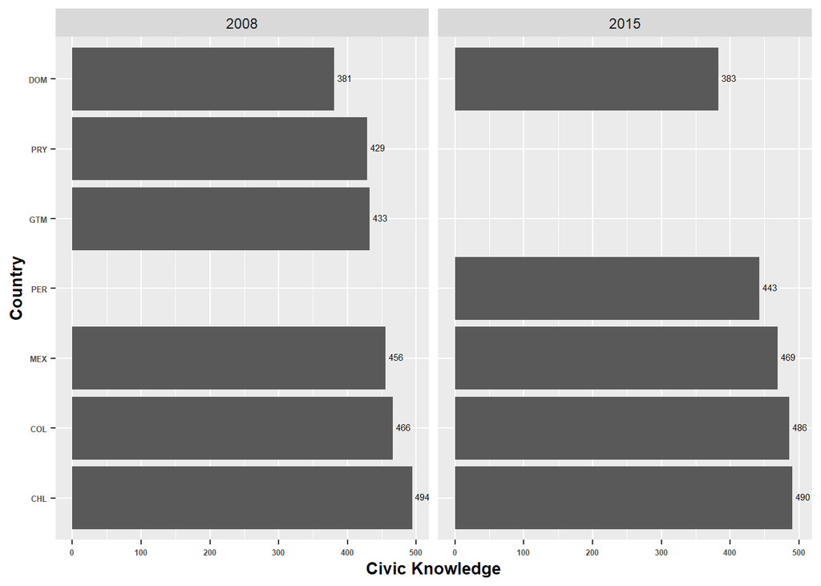

```r
#Graphs Bar
#All
civic_know <- ggplot(civic_country_mean, aes(reorder(to_label(country), -mean),mean), group = time)
civic_know <- civic_know +  geom_bar(stat = "summary") +
  facet_grid(~ time) +
  geom_text(aes(label = format(mean, digits = 2), vjust=0.3, hjust=-0.2), size=2, colour="black") +
  coord_flip() +
  theme(axis.text=element_text(size=5,face="bold"),
        axis.title=element_text(size=10,face="bold")) +
  labs(x="Country", y="Civic Knowledge")
civic_know
```

## Latin American 2009-2016: Dictatorship and civic knowledge

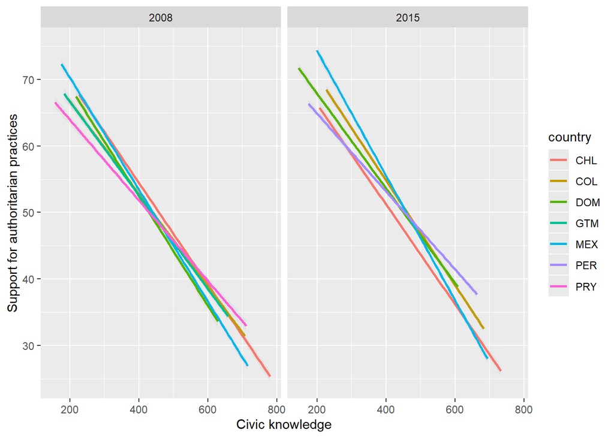

```r
#Dictatorships are justified when they bring economic benefits
scatter <- ggplot(dict, aes(civic_knowledge, l_autgov, colour = factor(country)))
    scatter + geom_smooth(method = "lm", alpha = 0.1) +
      facet_wrap(~ time) +
    labs(x = "Civic knowledge", y = "Support for authoritarian practices", colour = "country")
```

- Dictatorships are justified when they bring order and safety and civic knowledge

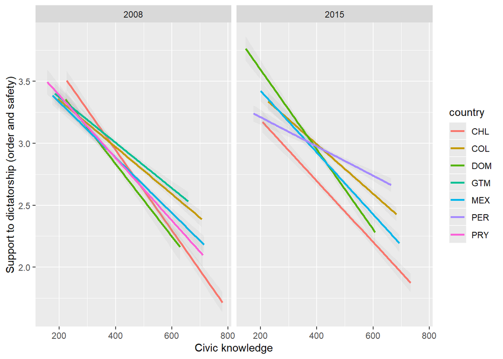

```r
#Dictatorships are justified when they bring order and safety
scatter <- ggplot(dict, aes(civic_knowledge, dict_safety, colour = factor(country)))
    scatter + geom_smooth(method = "lm", alpha = 0.1) +
      facet_wrap(~ time) +
    labs(x = "Civic knowledge", y = "Support to dictatorship (order and safety)", colour = "country")
```

- Dictatorships are justified (means of the previous two) and civic knowledge

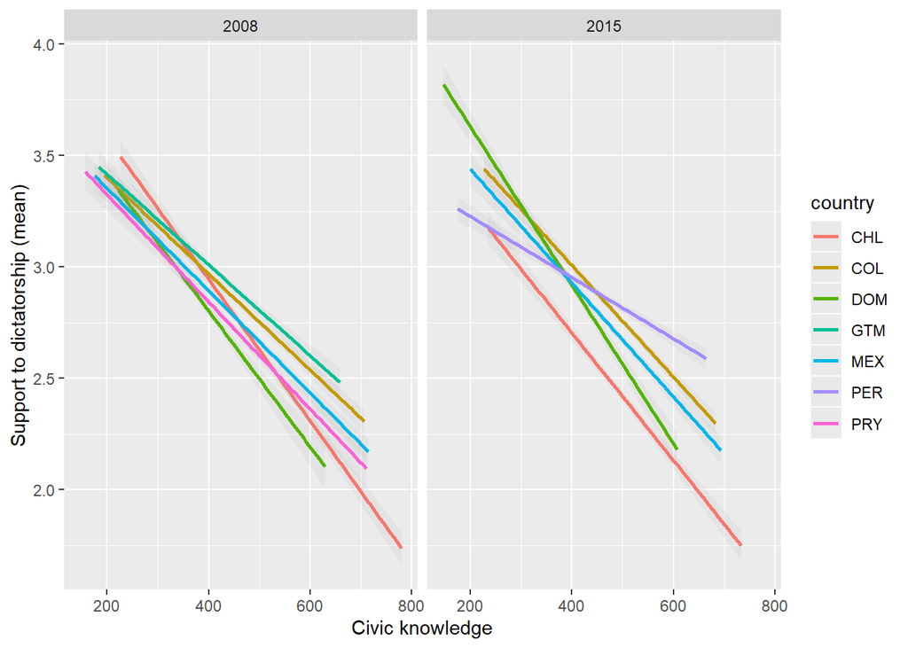

```r
#Dictatorships are justified mean
scatter <- ggplot(dict, aes(civic_knowledge, dict, colour = factor(country)))
    scatter + geom_smooth(method = "lm", alpha = 0.1) +
      facet_wrap(~ time) +
    labs(x = "Civic knowledge", y = "Support to dictatorship (mean)", colour = "country")
```

# Support for Dictatorship and institutional trust

## Latin American 2009-2016: Institutional trust

```r
in_trust09 <- dict2 %>% filter(time==2008)  %>% group_by(country) %>%
  dplyr::summarise(mean=mean(s_intrust),sd=sd(s_intrust),n=n()) %>%
  dplyr::mutate(se=sd/sqrt(n)) %>%
  mutate (time=2008)

in_trust16 <- dict2 %>% filter(time==2015)  %>% group_by(country) %>%
  dplyr::summarise(mean=mean(s_intrust),sd=sd(s_intrust),n=n()) %>%
  dplyr::mutate(se=sd/sqrt(n)) %>%
  mutate (time=2015)

in_trust_mean <- merge(in_trust09, in_trust16, all = T)

kable(in_trust_mean, align = c("cccccc"), caption = "Mean trust in civic institutions") %>%
  kable_styling(bootstrap_options = c("striped", "hover"))
```

| country | mean | sd | n | se | time |
| --- | --- | --- | --- | --- | --- |
| CHL | 47.06615 | 10.965115 | 4070 | 0.1718763 | 2015 |
| CHL | 49.81702 | 9.650716 | 4511 | 0.1436889 | 2008 |
| COL | 48.06496 | 9.497960 | 4461 | 0.1422048 | 2015 |
| COL | 49.35341 | 10.385844 | 4790 | 0.1500631 | 2008 |
| DOM | 54.14559 | 11.956145 | 2164 | 0.2570174 | 2008 |
| DOM | 54.98023 | 11.327530 | 2359 | 0.2332229 | 2015 |
| GTM | 46.91566 | 9.569341 | 2930 | 0.1767861 | 2008 |
| MEX | 48.46713 | 10.355470 | 5127 | 0.1446233 | 2008 |
| MEX | 49.61967 | 10.893892 | 4530 | 0.1618579 | 2015 |
| PER | 47.84578 | 9.585716 | 4169 | 0.1484597 | 2015 |
| PRY | 49.42522 | 9.333150 | 2148 | 0.2013776 | 2008 |

```
## No summary function supplied, defaulting to `mean_se()
## No summary function supplied, defaulting to `mean_se()
```

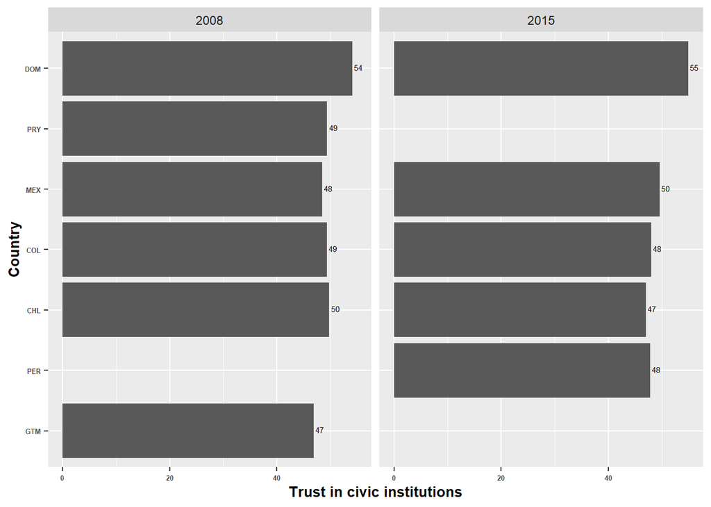

```r
#Graphs Bar
#All
bar_intrust <- ggplot(in_trust_mean, aes(reorder(to_label(country), mean),mean), group = time)
bar_intrust <- bar_intrust +  geom_bar(stat = "summary") +
  facet_grid(~ time) +
  geom_text(aes(label = format(mean, digits = 2), vjust=0.3, hjust=-0.2), size=2, colour="black") +
  coord_flip() +
  theme(axis.text=element_text(size=5,face="bold"),
        axis.title=element_text(size=10,face="bold")) +
  labs(x="Country", y="Trust in civic institutions")
bar_intrust
```

## Latin American 2009-2016: Dictatorship and institutional trust

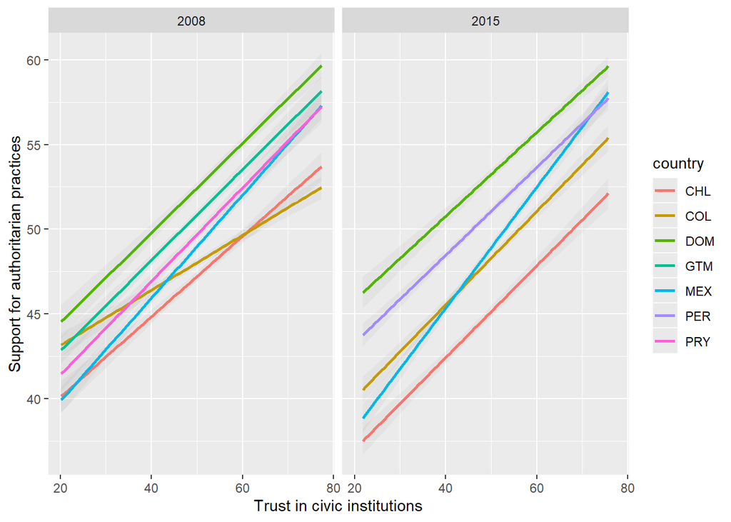

```r
#Dictatorships are justified when they bring economic benefits
scatter <- ggplot(dict, aes(s_intrust, l_autgov, colour = factor(country)))
    scatter + geom_smooth(method = "lm", alpha = 0.1) +
      facet_wrap(~ time) +
    labs(x = "Trust in civic institutions", y = "Support for authoritarian practices", colour = "country")
```

- Dictatorships are justified when they bring order and safety and institutional trust

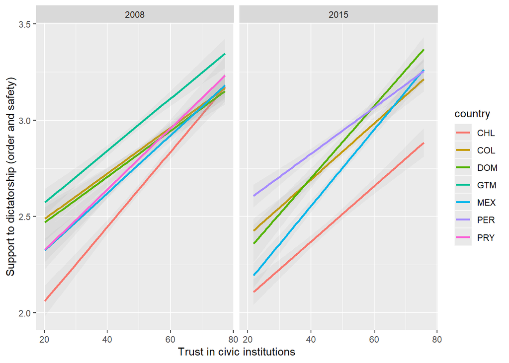

```r
#Dictatorships are justified when they bring order and safety
scatter <- ggplot(dict, aes(s_intrust, dict_safety, colour = factor(country)))
    scatter + geom_smooth(method = "lm", alpha = 0.1) +
      facet_wrap(~ time) +
    labs(x = "Trust in civic institutions", y = "Support to dictatorship (order and safety)", colour = "country")
```

- Dictatorships are justified (means of the previous two) and institutional trust

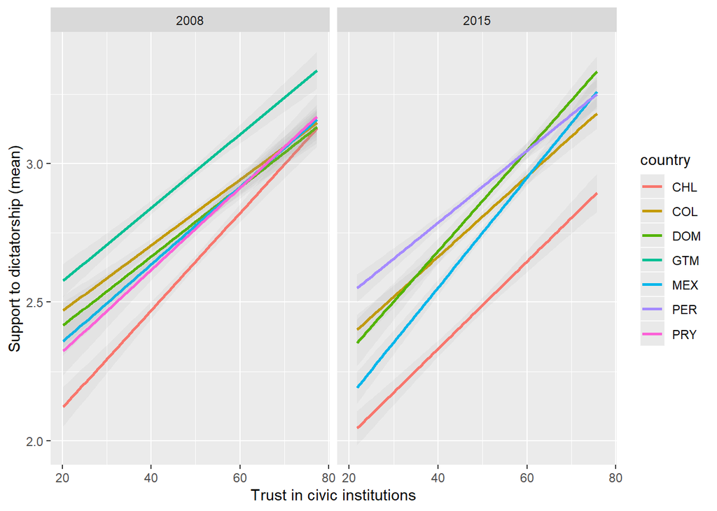

```r
#Dictatorships are justified mean
scatter <- ggplot(dict, aes(s_intrust, dict, colour = factor(country)))
    scatter + geom_smooth(method = "lm", alpha = 0.1) +
      facet_wrap(~ time) +
    labs(x = "Trust in civic institutions", y = "Support to dictatorship (mean)", colour = "country")
```

- Dictatorships are justified when they bring economic benefits and institutional trust

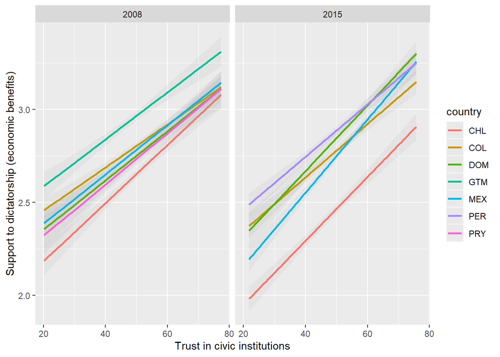

```r
#Dictatorships are justified when they bring economic benefits
scatter <- ggplot(dict, aes(s_intrust, dict_benefits, colour = factor(country)))
    scatter + geom_smooth(method = "lm", alpha = 0.1) +
      facet_wrap(~ time) +
    labs(x = "Trust in civic institutions", y = "Support to dictatorship (economic benefits)", colour = "country")
```

- Dictatorships are justified when they bring order and safety and institutional trust

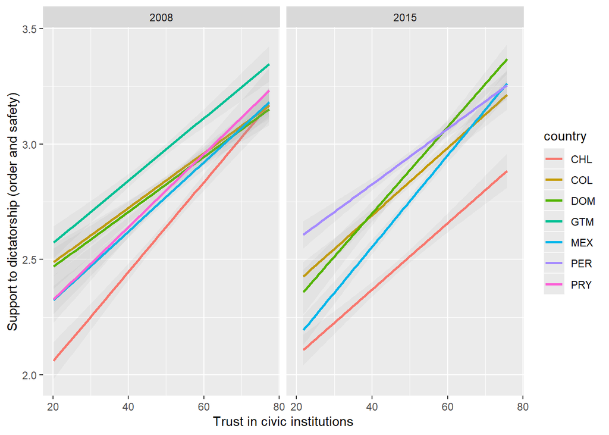

```r
#Dictatorships are justified when they bring order and safety
scatter <- ggplot(dict, aes(s_intrust, dict_safety, colour = factor(country)))
    scatter + geom_smooth(method = "lm", alpha = 0.1) +
      facet_wrap(~ time) +
    labs(x = "Trust in civic institutions", y = "Support to dictatorship (order and safety)", colour = "country")
```

- Dictatorships are justified (means of the previous two) and institutional trust

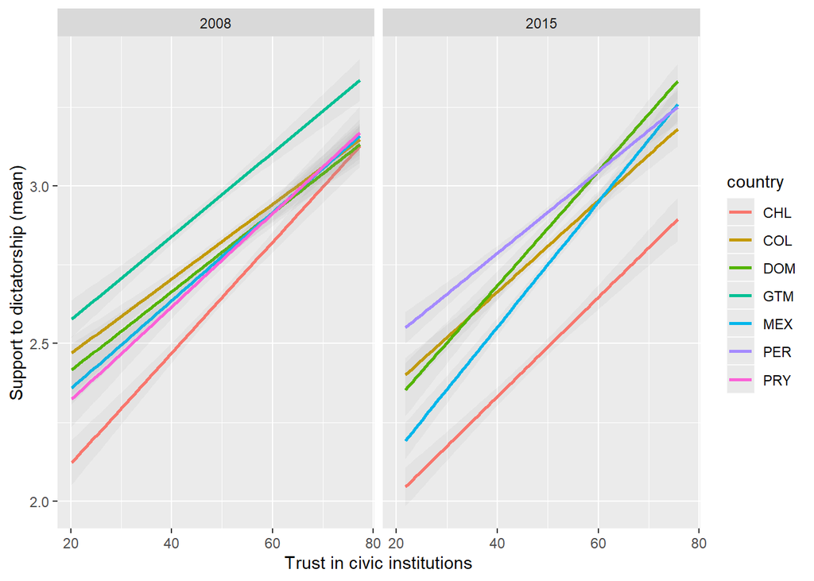

```r
#Dictatorships are justified mean
scatter <- ggplot(dict, aes(s_intrust, dict, colour = factor(country)))
    scatter + geom_smooth(method = "lm", alpha = 0.1) +
      facet_wrap(~ time) +
    labs(x = "Trust in civic institutions", y = "Support to dictatorship (mean)", colour = "country")
```